# Tarea 1 — Caja de herramientas de pronóstico

Autor/a

Andrés Felipe Cadavid Sanguino

Fecha de publicación

25 de septiembre de 2026

# 1 Introducción y convenciones

Este informe presenta una caja de herramientas de pronóstico escrita a mano en R: lectura de series con verificación de fechas, gráficos, correlograma, pruebas de hipótesis sobre la serie y sobre los errores, medidas de error y ocho métodos de pronóstico (media simple, media móvil, suavizamiento exponencial simple, doble media móvil, tendencias lineal, cuadrática y exponencial, y Holt) con la optimización de sus constantes. Cada método se aplica a una serie cuyo patrón corresponde a su supuesto, y un noveno ejemplo, el contraejemplo, aplica un método a una serie cuyo patrón lo contradice para mostrar en qué se nota la falla.

El código de las funciones vive en `R/` y aquí solo se carga; el código de cada ejemplo se muestra completo. Toda cifra del texto sale de código que corre al renderizar este documento. Los decimales llevan coma, los estadísticos cuatro cifras y los valores p tres (`< 0,001` cuando corresponde).

```r
invisible(lapply(sort(list.files("../R", pattern = "\\.R$", full.names = TRUE)), source))
set.seed(2026)  # ningún paso del informe es aleatorio; se fija por regla del enunciado
knitr::opts_chunk$set(fig.width = 8, fig.height = 4.6, fig.align = "center", out.width = "92%")
resumen <- list()  # cada ejemplo agrega su fila (ejemplo, serie, método, MASE del método y del referente)
# Misma definición que en ejemplos/ejemplos.R: una fila del resumen final.
.fila_resumen <- function(ejemplo, serie, fit, m_val, m_ref) {
  data.frame(ejemplo = ejemplo, serie = serie, metodo = fit$metodo,
             MASE_metodo = m_val$MASE, MASE_referente = m_ref$MASE)
}

# Formato de las cifras del texto: coma decimal, 4 cifras (n4), 2 cifras (n2), valor p (pv)
n4 <- function(x) .fmt_num(x, 4)
n2 <- function(x) .fmt_num(x, 2)
pv <- .fmt_p
# Tablas con coma decimal y 4 cifras
tab <- function(df, digitos = 4) knitr::kable(df, digits = digitos, format.args = list(decimal.mark = ","))
# Tabla de coeficientes de una tendencia: estimación, errores estándar ordinario y robusto (HAC), estadístico t
# con el robusto y los valores p con cada error estándar (t de Student con T - p grados de libertad)
tabla_coef <- function(fit) {
  t <- fit$parametros$tabla; gl <- fit$parametros$gl
  data.frame(Coeficiente = t$coeficiente, Estimación = t$estimacion, `EE ordinario` = t$ee_ordinario,
             `EE robusto` = t$ee_robusto, `t robusto` = t$t_robusto,
             `p robusto` = vapply(t$valor_p, pv, ""),
             `p ordinario` = vapply(2 * pt(-abs(t$estimacion / t$ee_ordinario), gl), pv, ""),
             check.names = FALSE)
}
# Notación científica con coma decimal, para diferencias del orden de 1e-12
cient <- function(x, digitos = 2) format(x, digits = digitos, scientific = TRUE, decimal.mark = ",")
# Una prueba de hipótesis en sus seis elementos; la lectura es el sexto
pp <- function(obj, lectura) cat(.reportar_prueba(obj, lectura), sep = "\n")
# Descripción de una serie con cifras verificadas por código (no escritas a mano)
descripcion <- function(x, nombre, d) {
  data.frame(
    Campo = c("Nombre en R", "Fuente (help)", "Unidad", "Frecuencia", "Inicio (año, período)",
              "Fin (año, período)", "Rango de fechas", "Observaciones"),
    Valor = c(nombre, attr(d, "fuente"), attr(d, "unidad"), frequency(x),
              paste(start(x), collapse = ", "), paste(end(x), collapse = ", "),
              paste(format(d$fecha[1]), "a", format(d$fecha[nrow(d)])), length(x))
  )
}
```

## Convenciones que fijan los números

Cuando el enunciado y las notas no fijan una decisión, se toma una, se documenta y se muestra su efecto. Estas son las que determinan las cifras de este documento.

- **Partición.** El tramo de validación son las últimas $h = \min\{12, \lfloor 0{,}2\,T\rfloor\}$ observaciones; el de estimación, las $T_{est} = T - h$ anteriores. Ningún parámetro se elige con el tramo de validación. En las series estacionales ($s = 4$ en `JohnsonJohnson`, $s = 12$ en `AirPassengers`) $h = 12$ cubre al menos un ciclo completo.
- **Errores de un paso.** $\hat Y_t$ usa solo información hasta $t-1$; el calentamiento del método queda en `NA`. En cada validación se declara $N$, el número de errores, que no es el $T$ de la serie.
- **Referente.** El pronóstico ingenuo $\hat Y_{T+h} = Y_T$, o el ingenuo estacional (el último ciclo repetido) en las series estacionales. El MASE se escala con el error absoluto medio del ingenuo de período $s$ **dentro del tramo de estimación**, de modo que un MASE menor que uno es mejor que ese ingenuo de un paso.
- **Correlograma.** La ACF se calcula a mano con divisor $T$ (una sola cifra en el denominador), la banda de ruido blanco es $\pm\, z_{0{,}975}/\sqrt{n}$ con $n$ el número de valores graficados (los errores, no la serie, cuando se grafican errores) y $m = \min\{\lfloor n/4\rfloor, 24\}$ rezagos.
- **Ljung–Box.** $Q_m$ se refiere a $\chi^2_{m-p}$, con $p$ el número de parámetros que el método estimó sobre la muestra (tabla siguiente); sobre la serie original $p = 0$.
- **Optimización.** `optimizar()` minimiza el MSE de un paso **dentro del tramo de estimación** sobre las rejillas del enunciado, con origen común: el MSE de todas las filas se calcula desde el primer período en que la ventana más exigente de la rejilla ya produce pronóstico ($t = 13$ en media móvil, $t = 24$ en doble media móvil, $t = 2$ en SES y Holt). En caso de empate gana la primera fila de la rejilla.
- **Tendencias.** Los `yhat` son los valores ajustados de una regresión que usa toda la muestra de estimación, así que no son pronósticos con información hasta $t-1$ y su MSE dentro de muestra es optimista frente al de los métodos de suavizamiento. El error estándar robusto es el de Newey–West (núcleo de Bartlett, $L = \lfloor 4\,(T/100)^{2/9}\rfloor$ rezagos, sin corrección por grados de libertad) y los valores p usan la $t$ de Student con $T-p$ grados de libertad. La tendencia exponencial se estima sobre $\ln Y_t$: su pronóstico $e^{\hat a + \hat\theta t}$ estima la mediana condicional y no la media.
- **Durbin–Watson.** Sin valor p exacto; se decide con las cotas $d_L$ y $d_U$ al 5 % de la tabla de Savin y White (1977). Como la tabla no cubre todos los $N$ de este trabajo, las cotas se calcularon de forma exacta con la definición de Durbin y Watson (1951) y la integral de Imhof (1961), y ese cálculo reproduce doce filas de la tabla con diferencias de a lo sumo $0{,}005$. Se redondean a dos decimales, como la tabla, y para los métodos de suavizamiento se usa $k' = 1$ (aproximación declarada: no hay matriz de diseño).
- **MAPE.** Si algún valor evaluado es cero el MAPE no está definido y se reporta `NA` con aviso; el dato no se omite en silencio (ocurre en `discoveries`).

Tabla 1: Parámetros estimados $p$ que se restan a los grados de libertad de Ljung–Box.

| Método | $p$ | Qué se estimó |
| --- | --- | --- |
| Media simple | 0 | nada se elige sobre la muestra |
| Media móvil | 1 | $k$ |
| Suavizamiento exponencial simple | 1 | $\alpha$ |
| Doble media móvil | 1 | $k$ |
| Tendencia lineal | 2 | $\beta_0, \beta_1$ |
| Tendencia cuadrática | 3 | $\beta_0, \beta_1, \beta_2$ |
| Tendencia exponencial | 2 | $a, \theta$ |
| Holt | 2 | $\alpha, \beta$ |

### Sobre el uso de IA

Este trabajo se desarrolló de forma conjunta entre el estudiante y Claude (Anthropic), utilizado como asistente de programación. El proyecto partió de una propuesta inicial aportada por el estudiante (borradores del código, del informe y del README, y la especificación del proyecto). El estudiante dirigió el proceso, aprobó el plan de cada fase, revisó y modificó partes del código; Claude revisó, corrigió, reescribió y amplió ese código, ejecutó las verificaciones contra R y ensambló el informe. Las interpretaciones de los ejemplos 1 a 6 (lectura del patrón, lectura de cada prueba, optimización, medidas, conclusión y recomendación) las redactó el estudiante; Claude las integró convirtiendo cada cifra en código en línea y contrastándolas con los resultados de la corrida. Las interpretaciones de los ejemplos 7 y 8 y del contraejemplo, y los textos descriptivos de todos los ejemplos, siguen con la redacción de Claude. El detalle de qué se pidió, qué se recibió y qué se verificó está en la declaración de uso de IA del `README.md`.

# 2 Verificaciones contra R

Antes de usar las funciones se comprueban contra las de R. Estas verificaciones son el único lugar de este documento (junto a `ejemplos.R`) donde aparecen `acf()`, `lm()` y `Box.test()`. Cada fila reporta la diferencia máxima observada y su tolerancia; el documento se detiene si alguna la supera.

Las equivalencias de los métodos se miden como error **relativo** a $\max|y|$. La razón se ve con la serie `austres`, cuyos datos tienen un decimal y valen cerca de $1{,}4\times 10^{4}$: se compara la media simple recursiva y la media directa `mean(y[1:t])` con una referencia exacta (los datos por diez son enteros y su suma acumulada es exacta en punto flotante, con una sola división al final).

```r
y <- as.numeric(austres); n <- length(y)
recursiva <- ajustar_media(y)$yhat[-1]
directa   <- vapply(1:(n - 1), function(t) mean(y[1:t]), 0)
exacta    <- cumsum(round(y * 10))[1:(n - 1)] / (1:(n - 1)) / 10
dif_rec_dir <- max(abs(recursiva - directa)); dif_dir_exa <- max(abs(directa - exacta))
ulp <- 2^(floor(log2(max(y))) - 52)   # distancia entre dos números representables en max(y)
```

La recursión difiere del promedio directo en 3,6e-12 y `mean()` difiere de la referencia exacta en 1,8e-12, mientras que un ulp en el mayor de los datos mide 3,6e-12: las diferencias son del orden de un ulp, ruido de punto flotante y no un error del método. Una cota absoluta de $10^{-12}$ no la cumple ninguna implementación correcta con estos datos, así que se mide el error relativo a $\max|y|$ con esa misma cota.

Primero, la ACF a mano, su banda y la prueba de Ljung–Box contra `acf()` y `Box.test()`:

```r
fila_v <- function(prueba, dif, tol) data.frame(prueba = prueba, dif = dif, tol = tol, ok = dif < tol)

series0 <- list(Nile = Nile, LakeHuron = LakeHuron, austres = austres, discoveries = discoveries,
                airmiles = airmiles, JohnsonJohnson = JohnsonJohnson, AirPassengers = AirPassengers)

# ACF a mano, banda y Ljung–Box contra acf() y Box.test()
dif_acf <- dif_banda <- dif_Q <- dif_Qp <- 0
for (x in series0) {
  y <- as.numeric(x); n <- length(y)
  for (m in unique(c(4, min(floor(n / 4), 24)))) {
    cg <- correlograma(y, m)
    ref <- acf(y, lag.max = m, plot = FALSE)
    dif_acf <- max(dif_acf, max(abs(cg$acf - ref$acf[-1])))
    dif_banda <- max(dif_banda, abs(cg$banda - qnorm((1 + 0.95) / 2) / sqrt(ref$n.used)))
    for (p in 0:min(3, m - 1)) {
      lb <- ljung_box(cg$acf, n, m, p)
      bt <- Box.test(y, lag = m, type = "Ljung-Box", fitdf = p)
      dif_Q <- max(dif_Q, abs(lb$estadistico - bt$statistic) / bt$statistic)
      dif_Qp <- max(dif_Qp, abs(lb$valor_p - bt$p.value))
    }
  }
}
```

Segundo, las equivalencias de los métodos (media móvil recursiva contra el promedio directo por ventana, SES contra su promedio ponderado finito, doble media móvil contra su definición y Holt contra su forma de corrección de error):

```r
# Equivalencias de los métodos (error relativo a max|y|)
dif_mm <- dif_ses <- dif_pesos <- dif_dmm <- dif_holt <- 0
for (x in series0) {
  y <- as.numeric(x); n <- length(y); esc <- max(abs(y))
  for (k in 2:12) {                                     # MM recursiva vs promedio directo por ventana
    directa <- rep(NA_real_, n)
    for (t in (k + 1):n) directa[t] <- mean(y[(t - k):(t - 1)])
    dif_mm <- max(dif_mm, max(abs(ajustar_mm(y, k)$yhat - directa), na.rm = TRUE) / esc)
    if (2 * k - 1 <= n) {                               # DMM (un recorrido) vs definición directa
      mm <- rep(NA_real_, n); for (t in k:n) mm[t] <- mean(y[(t - k + 1):t])
      dm <- rep(NA_real_, n); for (t in (2 * k - 1):n) dm[t] <- mean(mm[(t - k + 1):t])
      yh <- c(NA, (2 * mm - dm + 2 / (k - 1) * (mm - dm))[-n])
      dif_dmm <- max(dif_dmm, max(abs(ajustar_dmm(y, k)$yhat - yh), na.rm = TRUE) / esc)
    }
  }
  for (a in c(0.05, 0.15, 0.5, 0.98)) {                 # SES vs promedio ponderado finito
    f <- ajustar_ses(y, a)
    pond <- vapply(2:n, function(t) {
      i <- 0:(t - 2)
      a * sum((1 - a)^i * y[t - i]) + (1 - a)^(t - 1) * y[1]
    }, 0)
    suma_pesos <- vapply(2:n, function(t) a * sum((1 - a)^(0:(t - 2))) + (1 - a)^(t - 1), 0)
    dif_pesos <- max(dif_pesos, max(abs(suma_pesos - 1)))
    dif_ses <- max(dif_ses, max(abs(c(f$yhat[3:n], f$parametros$siguiente) - pond)) / esc)
  }
  for (ab in list(c(0.1, 0.1), c(0.3, 0.4), c(0.9, 0.05))) {   # Holt vs forma de corrección de error
    f <- ajustar_holt(y, ab[1], ab[2])
    e <- y - f$yhat; L <- f$parametros$nivel; Tt <- f$parametros$pendiente; t <- 2:n
    dif_holt <- max(dif_holt, max(abs(L[t] - (L[t - 1] + Tt[t - 1] + ab[1] * e[t])),
                                  abs(Tt[t] - (Tt[t - 1] + ab[1] * ab[2] * e[t]))) / esc)
  }
}
```

Tercero, los coeficientes de las tendencias contra `lm()` y las cifras publicadas en las notas de la Clase 3 (precios de cierre) y de la Clase 4 (créditos al consumo):

```r
# Tendencias: coeficientes contra lm()
dif_lm <- 0
for (cs in list(list(LakeHuron, "lineal"), list(airmiles, "cuadratica"), list(airmiles, "exponencial"),
                list(JohnsonJohnson, "exponencial"), list(Nile, "cuadratica"))) {
  y <- as.numeric(cs[[1]]); t <- seq_along(y)
  fit_lm <- switch(cs[[2]], lineal = lm(y ~ t), cuadratica = lm(y ~ t + I(t^2)), exponencial = lm(log(y) ~ t))
  dif_lm <- max(dif_lm, max(abs(unname(ajustar_tendencia(y, cs[[2]])$parametros$coef) - unname(coef(fit_lm)))))
}

# Cifras publicadas en las notas: Clase 3 (precios de cierre, mayo-diciembre) y Clase 4
# (créditos al consumo, once meses). Las notas publican 4 cifras significativas o 2 decimales,
# por eso la tolerancia es media unidad de la última cifra publicada.
precio <- c(18.43, 19.98, 19.51, 20.63, 19.78, 21.25, 21.18, 22.14)
credito <- c(133, 155, 165, 171, 194, 231, 274, 312, 313, 333, 343)
m_mm3 <- medidas(precio, ajustar_mm(precio, 3)$yhat, precio)
ses15 <- ajustar_ses(precio, 0.15); yh_ses <- ses15$yhat; yh_ses[2:3] <- NA   # origen común t = 4
m_ses15 <- medidas(precio, yh_ses, precio)
f_dmm3 <- ajustar_dmm(credito, 3); m_dmm3 <- medidas(credito, f_dmm3$yhat, credito)
f_holt <- ajustar_holt(credito, 0.3, 0.4); m_holt <- medidas(credito, f_holt$yhat, credito)

verif <- do.call(rbind, list(
  fila_v("ACF a mano vs acf() (7 series, 2 valores de m)", dif_acf, 1e-12),
  fila_v("Banda vs qnorm(0,975)/sqrt(n.used) de plot.acf", dif_banda, 1e-12),
  fila_v("Q de Ljung-Box vs Box.test, p = 0..3 (relativa)", dif_Q, 1e-12),
  fila_v("Valor p de Ljung-Box vs Box.test con fitdf = p", dif_Qp, 1e-12),
  fila_v("MM recursiva vs directa, k = 2..12 (relativa)", dif_mm, 1e-12),
  fila_v("SES vs promedio ponderado finito (relativa)", dif_ses, 1e-12),
  fila_v("SES: los pesos suman 1", dif_pesos, 1e-12),
  fila_v("DMM un recorrido vs definición directa (relativa)", dif_dmm, 1e-12),
  fila_v("Holt vs forma de corrección de error (relativa)", dif_holt, 1e-12),
  fila_v("Coeficientes de las tendencias vs lm()", dif_lm, 1e-8),
  fila_v("Clase 3: MM(3) MSE, MAD y MAPE", max(abs(c(m_mm3$MSE - 1.1621, m_mm3$MAD - 0.9780, (m_mm3$MAPE - 4.607) / 10))), 5e-5),
  fila_v("Clase 3: SES(0,15) en origen común, MSE", abs(m_ses15$MSE - 3.3706), 5e-5),
  fila_v("Clase 4: DMM(3) MSE y pronósticos", max(abs(c(m_dmm3$MSE - 841.24, f_dmm3$pronosticar(3) - c(356.56, 370.00, 383.44)))), 5e-3),
  fila_v("Clase 4: Holt(0,3; 0,4) MSE y pronósticos", max(abs(c(m_holt$MSE - 1133.08, f_holt$pronosticar(3) - c(387.15, 414.97, 442.80)))), 5e-3)
))
verif_imp <- verif; verif_imp$dif <- format(verif$dif, digits = 3, scientific = TRUE)
verif_imp$tol <- format(verif$tol, scientific = TRUE)
stopifnot("alguna verificación del Bloque 0 superó su tolerancia" = all(verif$ok))

verif_imp  # la tabla, como última expresión del chunk
```

| prueba | dif | tol | ok |
| --- | --- | --- | --- |
| ACF a mano vs acf() (7 series, 2 valores de m) | 5.55e-16 | 1e-12 | TRUE |
| Banda vs qnorm(0,975)/sqrt(n.used) de plot.acf | 0.00e+00 | 1e-12 | TRUE |
| Q de Ljung-Box vs Box.test, p = 0..3 (relativa) | 1.70e-15 | 1e-12 | TRUE |
| Valor p de Ljung-Box vs Box.test con fitdf = p | 1.04e-16 | 1e-12 | TRUE |
| MM recursiva vs directa, k = 2..12 (relativa) | 1.37e-15 | 1e-12 | TRUE |
| SES vs promedio ponderado finito (relativa) | 9.77e-16 | 1e-12 | TRUE |
| SES: los pesos suman 1 | 9.99e-16 | 1e-12 | TRUE |
| DMM un recorrido vs definición directa (relativa) | 3.32e-15 | 1e-12 | TRUE |
| Holt vs forma de corrección de error (relativa) | 2.38e-16 | 1e-12 | TRUE |
| Coeficientes de las tendencias vs lm() | 5.08e-11 | 1e-08 | TRUE |
| Clase 3: MM(3) MSE, MAD y MAPE | 4.89e-05 | 5e-05 | TRUE |
| Clase 3: SES(0,15) en origen común, MSE | 1.11e-05 | 5e-05 | TRUE |
| Clase 4: DMM(3) MSE y pronósticos | 4.44e-03 | 5e-03 | TRUE |
| Clase 4: Holt(0,3; 0,4) MSE y pronósticos | 3.24e-03 | 5e-03 | TRUE |

Las 14 verificaciones pasan: la mayor diferencia relativa de las equivalencias es 3,32e-15, la de los coeficientes contra `lm()` es 5,08e-11 (tolerancia $10^{-8}$) y las cifras de las notas se reproducen dentro de media unidad de la última cifra publicada.

# 3 Ejemplo 1. Media simple sobre `discoveries`

## 3.1 Descripción de la serie

```r
x <- discoveries
d <- leer_serie(x,
                fuente = "The World Almanac and Book of Facts, 1975 Edition, pages 315-318 (paquete datasets, discoveries)",
                unidad = "Descubrimientos importantes por año (número)")
descripcion(x, "discoveries", d)
```

| Campo | Valor |
| --- | --- |
| Nombre en R | discoveries |
| Fuente (help) | The World Almanac and Book of Facts, 1975 Edition, pages 315-318 (paquete datasets, discoveries) |
| Unidad | Descubrimientos importantes por año (número) |
| Frecuencia | 1 |
| Inicio (año, período) | 1860, 1 |
| Fin (año, período) | 1959, 1 |
| Rango de fechas | 1860-01-01 a 1959-01-01 |
| Observaciones | 100 |

La serie cuenta los «grandes» inventos y descubrimientos científicos de cada año. Al ser un conteo puede valer cero, y de hecho hay 9 años sin descubrimientos: por eso el MAPE no está definido en este ejemplo.

## 3.2 Patrón de la serie

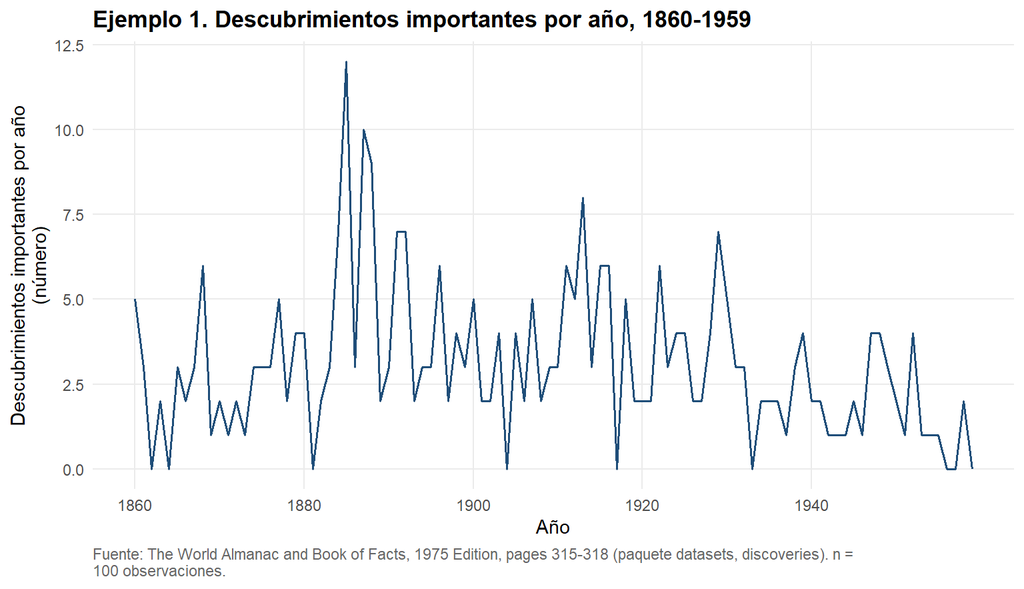

```r
graficar_serie(d, "Ejemplo 1. Descubrimientos importantes por año, 1860-1959")
```

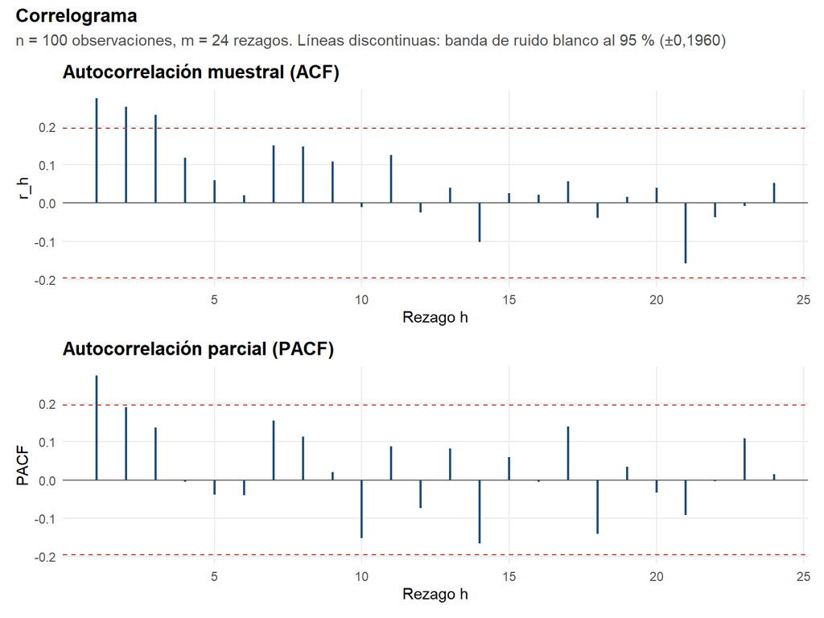

```r
cg <- correlograma(d)
cg$grafico
```

Contraste individual de las autocorrelaciones que sostienen la lectura y prueba conjunta sobre la serie ($p = 0$: no se ha estimado nada):

```r
n_total <- nrow(d)
r_1 <- .contraste_rh(cg$acf, n_total, 1)
pp(r_1, paste0("La autocorrelación en el rezago 1 fue de ", n4(cg$acf[1]), " y quedó por encima de la banda de ±", n4(cg$banda),
               ", por lo que se rechaza la hipótesis de que sea igual a cero. Esto indica que existe cierta relación entre los ",
               "descubrimientos de un año y los del año anterior. Aun así, solo ", sum(abs(cg$acf) > cg$banda), " de los ", cg$m,
               " rezagos están por fuera de la banda y todos se encuentran en los primeros rezagos, por lo que la dependencia ",
               "no parece mantenerse durante mucho tiempo."))
```

**Contraste individual de la autocorrelación en el rezago h = 1** (n = 100)

1. **Hipótesis.** $H_0:\ \rho_{1} = 0$; $H_1:\ \rho_{1} \neq 0$.
2. **Estadístico y distribución bajo $H_0$.** $T^* = \dfrac{r_h}{\sqrt{1/n}} = \sqrt{n}\, r_h\ \overset{H_0}{\approx}\ N(0,1)$.
3. **Región de rechazo al 5 %.** $|T^*| > z_{0{,}975} = 1,9600$, es decir $|r_{1}| > 0,1960$.
4. **Valor observado.** estadístico observado = 2,7414; valor p = 0,006.
5. **Decisión.** Se rechaza $H_0$ (nivel de significancia del 5 %).
6. **Lectura.** La autocorrelación en el rezago 1 fue de 0,2741 y quedó por encima de la banda de ±0,1960, por lo que se rechaza la hipótesis de que sea igual a cero. Esto indica que existe cierta relación entre los descubrimientos de un año y los del año anterior. Aun así, solo 3 de los 24 rezagos están por fuera de la banda y todos se encuentran en los primeros rezagos, por lo que la dependencia no parece mantenerse durante mucho tiempo.

```r
r_4 <- .contraste_rh(cg$acf, n_total, 4)
pp(r_4, paste0("En el rezago 4 la autocorrelación baja hasta ", n4(cg$acf[4]), " y queda dentro de la banda de ±", n4(cg$banda),
               ". Por lo tanto, no se rechaza que sea cero. Esto muestra que la relación entre los años se va perdiendo después ",
               "de los primeros rezagos. Si existiera una tendencia clara, se esperaría que las autocorrelaciones se mantuvieran ",
               "positivas durante más tiempo, cosa que aquí no sucede."))
```

**Contraste individual de la autocorrelación en el rezago h = 4** (n = 100)

1. **Hipótesis.** $H_0:\ \rho_{4} = 0$; $H_1:\ \rho_{4} \neq 0$.
2. **Estadístico y distribución bajo $H_0$.** $T^* = \dfrac{r_h}{\sqrt{1/n}} = \sqrt{n}\, r_h\ \overset{H_0}{\approx}\ N(0,1)$.
3. **Región de rechazo al 5 %.** $|T^*| > z_{0{,}975} = 1,9600$, es decir $|r_{4}| > 0,1960$.
4. **Valor observado.** estadístico observado = 1,1881; valor p = 0,235.
5. **Decisión.** No se rechaza $H_0$ (nivel de significancia del 5 %).
6. **Lectura.** En el rezago 4 la autocorrelación baja hasta 0,1188 y queda dentro de la banda de ±0,1960. Por lo tanto, no se rechaza que sea cero. Esto muestra que la relación entre los años se va perdiendo después de los primeros rezagos. Si existiera una tendencia clara, se esperaría que las autocorrelaciones se mantuvieran positivas durante más tiempo, cosa que aquí no sucede.

```r
lb0 <- ljung_box(cg$acf, n_total, cg$m, 0)
pp(lb0, paste0("El estadístico Ljung–Box fue ", n4(lb0$estadistico), " y el valor p fue ", pv(lb0$valor_p),
               ". Como está ligeramente por encima del 5 %, no se rechaza la hipótesis nula. Esto indica que, considerando los ",
               "primeros ", cg$m, " rezagos en conjunto, no hay suficiente evidencia para decir que exista una dependencia fuerte. ",
               "De todas formas, el resultado está muy cerca del límite, así que no se puede afirmar que la serie no tenga ninguna ",
               "estructura, sino que la dependencia que presenta es relativamente débil y se concentra principalmente en los ",
               "primeros rezagos."))
```

**Prueba de Ljung–Box** (n = 100)

1. **Hipótesis.** $H_0:\ \rho_1 = \rho_2 = \cdots = \rho_m = 0$; $H_1:\ \exists\, h \le m$ con $\rho_h \neq 0$.
2. **Estadístico y distribución bajo $H_0$.** $Q_m = T(T+2)\sum_{h=1}^{m} \dfrac{r_h^2}{T-h}\ \overset{H_0}{\sim}\ \chi^2_{m-p}$; $m = 24$, $p = 0$, luego los grados de libertad son $m - p = 24$.
3. **Región de rechazo al 5 %.** $Q_m > \chi^2_{0{,}95;\,24} = 36,4150$.
4. **Valor observado.** estadístico observado = 36,2540; valor p = 0,052.
5. **Decisión.** No se rechaza $H_0$ (nivel de significancia del 5 %).
6. **Lectura.** El estadístico Ljung–Box fue 36,2540 y el valor p fue 0,052. Como está ligeramente por encima del 5 %, no se rechaza la hipótesis nula. Esto indica que, considerando los primeros 24 rezagos en conjunto, no hay suficiente evidencia para decir que exista una dependencia fuerte. De todas formas, el resultado está muy cerca del límite, así que no se puede afirmar que la serie no tenga ninguna estructura, sino que la dependencia que presenta es relativamente débil y se concentra principalmente en los primeros rezagos.

**Lectura del patrón.** La serie se mantiene alrededor de unos 3 descubrimientos por año y no se observa una tendencia clara. La recta de tendencia solo explica el 4,53 % de la variación y los promedios de las dos mitades de la serie son relativamente cercanos, 3,44 y 2,76. Por esto, usar una media simple tiene sentido, ya que el método supone que la serie se mantiene alrededor de un nivel más o menos constante.

Sin embargo, el supuesto no se cumple perfectamente, porque hay una pequeña autocorrelación en los primeros rezagos y se nota una ligera disminución del nivel. Esto se revisará con las pruebas sobre los errores.

## 3.3 Partición

```r
h <- min(12, floor(0.2 * n_total)); T_est <- n_total - h
est <- d[seq_len(T_est), ]; val <- d[T_est + seq_len(h), ]
```

La serie tiene $T = 100$ observaciones y $h = \min\{12, \lfloor 0{,}2 \cdot 100\rfloor\} = 12$. El tramo de estimación es de 1860 a 1947 ($T_{est} = 88$) y el de validación de 1948 a 1959 ($h = 12$).

## 3.4 Ajuste y medidas

La media simple no tiene constantes ni ventanas por elegir, así que no se usa `optimizar()`. Se ajusta sobre el tramo de estimación y se compara con el pronóstico ingenuo $\hat Y_{T+h} = Y_T$ sobre el mismo tramo de validación:

```r
fit <- ajustar_media(est$y)
pron <- fit$pronosticar(h)
ref <- rep(est$y[T_est], h)                       # ingenuo: el último valor observado
m_in <- .medir(est$y, fit$yhat, est$y)            # un paso, dentro del tramo de estimación
```

```
  [esperado] MAPE no definido: hay ceros entre los datos evaluados; se reporta NA.
```

```r
m_val <- .medir(val$y, pron, est$y)               # h pronósticos sobre el tramo de validación
```

```
  [esperado] MAPE no definido: hay ceros entre los datos evaluados; se reporta NA.
```

```r
m_ref <- .medir(val$y, ref, est$y)                # el ingenuo, mismo tramo y mismo h
```

```
  [esperado] MAPE no definido: hay ceros entre los datos evaluados; se reporta NA.
```

```r
tab(.tabla_medidas(m_in, m_val, m_ref, "Ingenuo"))
```

| caso | N | MSE | MAD | MAPE | MASE |
| --- | --- | --- | --- | --- | --- |
| Método, un paso (estimación) | 87 | 5,4246 | 1,7663 | NA | 0,8306 |
| Método, h pronósticos (validación) | 12 | 4,8801 | 1,9545 | NA | 0,9192 |
| Ingenuo, h pronósticos (validación) | 12 | 7,7500 | 2,4167 | NA | 1,1365 |

El nivel estimado es $\bar Y_{T_{est}} =$ 3,3068 descubrimientos por año. El MAPE es `NA` en las tres filas porque hay ceros entre los datos evaluados; la función avisa y no omite el dato. El MASE se escala con el error absoluto medio del ingenuo de un paso en el tramo de estimación (2,1264).

## 3.5 Validación de los errores de un paso

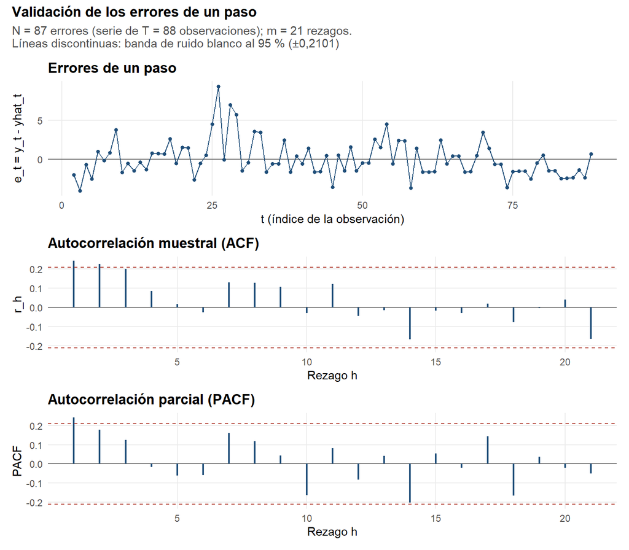

```r
cot <- .cotas("ej01", sum(!is.na(fit$errores)))
ve <- validar_errores(fit$errores, fit$n_param, T_est, cot$dL, cot$dU)
ve$grafico
```

Son $N = 87$ errores de un paso (uno menos que $T_{est}$: el primero no tiene pronóstico), con $m = 21$ rezagos y banda de ±0,2101, calculada sobre $N$.

```r
pp(ve$t_media, paste0("El error medio fue ", n4(mean(ve$e)), ", con una desviación de ", n4(sd(ve$e)), ", y el valor p fue ",
                      pv(ve$t_media$valor_p), ". Como no se rechaza la hipótesis de media cero, no hay evidencia de que el método ",
                      "sobrestime o subestime sistemáticamente los valores dentro de la muestra."))
```

**Prueba t de media cero de los errores** (n = 87)

1. **Hipótesis.** $H_0:\ \mu_e = 0$; $H_1:\ \mu_e \neq 0$.
2. **Estadístico y distribución bajo $H_0$.** $t = \dfrac{\bar{e}}{s_e/\sqrt{N}}\ \overset{H_0}{\sim}\ t_{N-1}$; grados de libertad: $86$.
3. **Región de rechazo al 5 %.** $|t| > t_{0{,}975;\,86} = 1,9879$.
4. **Valor observado.** estadístico observado = 0,1943; valor p = 0,846.
5. **Decisión.** No se rechaza $H_0$ (nivel de significancia del 5 %).
6. **Lectura.** El error medio fue 0,0488, con una desviación de 2,3421, y el valor p fue 0,846. Como no se rechaza la hipótesis de media cero, no hay evidencia de que el método sobrestime o subestime sistemáticamente los valores dentro de la muestra.

```r
pp(ve$ljung_box, paste0("El valor p fue ", pv(ve$ljung_box$valor_p), ", por lo que no se rechaza que los errores sean ",
                        "incorrelacionados en conjunto. Sin embargo, los rezagos ",
                        paste(which(abs(ve$correlograma$acf) > ve$correlograma$banda), collapse = " y "),
                        " sí están por fuera de la banda, con autocorrelaciones de ", n4(ve$correlograma$acf[1]), " y ",
                        n4(ve$correlograma$acf[2]), ". Esto muestra que la prueba conjunta no detecta una estructura ",
                        "suficientemente fuerte cuando se consideran todos los rezagos al mismo tiempo, aunque sí existe cierta ",
                        "relación en los primeros."))
```

**Prueba de Ljung–Box sobre los errores** (n = 87)

1. **Hipótesis.** $H_0:\ \rho_1 = \rho_2 = \cdots = \rho_m = 0$; $H_1:\ \exists\, h \le m$ con $\rho_h \neq 0$.
2. **Estadístico y distribución bajo $H_0$.** $Q_m = T(T+2)\sum_{h=1}^{m} \dfrac{r_h^2}{T-h}\ \overset{H_0}{\sim}\ \chi^2_{m-p}$; $m = 21$, $p = 0$, luego los grados de libertad son $m - p = 21$.
3. **Región de rechazo al 5 %.** $Q_m > \chi^2_{0{,}95;\,21} = 32,6706$.
4. **Valor observado.** estadístico observado = 27,6425; valor p = 0,151.
5. **Decisión.** No se rechaza $H_0$ (nivel de significancia del 5 %).
6. **Lectura.** El valor p fue 0,151, por lo que no se rechaza que los errores sean incorrelacionados en conjunto. Sin embargo, los rezagos 1 y 2 sí están por fuera de la banda, con autocorrelaciones de 0,2426 y 0,2254. Esto muestra que la prueba conjunta no detecta una estructura suficientemente fuerte cuando se consideran todos los rezagos al mismo tiempo, aunque sí existe cierta relación en los primeros.

```r
pp(ve$jarque_bera, paste0("La prueba de Jarque–Bera dio un valor p ", pv(ve$jarque_bera$valor_p), ", por lo que se rechaza ",
                          "la normalidad de los errores. Esto se puede relacionar con que la variable es un conteo y puede tomar ",
                          "valores bastante alejados del promedio hacia la derecha. Aunque los errores no sean normales, la ",
                          "prueba t de media cero sigue siendo razonable en este caso por el tamaño de la muestra, que es de ",
                          ve$n, " errores."))
```

**Prueba de Jarque–Bera** (n = 87)

1. **Hipótesis.** $H_0:\ A = 0\ \text{y}\ K = 3$ (errores normales); $H_1:\ A \neq 0\ \text{o}\ K \neq 3$.
2. **Estadístico y distribución bajo $H_0$.** $JB = \dfrac{N}{6}\left[A^2 + \dfrac{(K-3)^2}{4}\right]\ \overset{H_0}{\sim}\ \chi^2_2$, con $A = m_3/m_2^{3/2}$ la asimetría y $K = m_4/m_2^2$ la curtosis muestrales; grados de libertad: $2$.
3. **Región de rechazo al 5 %.** $JB > \chi^2_{0{,}95;\,2} = 5,9915$.
4. **Valor observado.** estadístico observado = 41,2674; valor p < 0,001.
5. **Decisión.** Se rechaza $H_0$ (nivel de significancia del 5 %).
6. **Lectura.** La prueba de Jarque–Bera dio un valor p < 0,001, por lo que se rechaza la normalidad de los errores. Esto se puede relacionar con que la variable es un conteo y puede tomar valores bastante alejados del promedio hacia la derecha. Aunque los errores no sean normales, la prueba t de media cero sigue siendo razonable en este caso por el tamaño de la muestra, que es de 87 errores.

```r
pp(ve$durbin_watson, paste0("El estadístico Durbin–Watson fue ", n4(ve$durbin_watson$estadistico), " y quedó por debajo de d_L = ",
                            n2(cot$dL), ", por lo que se rechaza la ausencia de autocorrelación positiva de orden uno. Esto ",
                            "coincide con el resultado de la ACF, donde r_1 = ", n4(ve$correlograma$acf[1]), ". En otras ",
                            "palabras, todavía queda cierta información del error anterior que la media simple no está ",
                            "utilizando. Que Durbin–Watson detecte un problema que Ljung–Box no alcanzó a rechazar es ",
                            "compatible con que las pruebas tienen potencia distinta: Durbin–Watson apunta a una sola alternativa ",
                            "(autocorrelación de orden uno), mientras que Ljung–Box reparte su potencia entre todos los rezagos."))
```

**Prueba de Durbin–Watson** (n = 87)

1. **Hipótesis.** $H_0:\ \rho = 0$ (sin autocorrelación de orden 1); $H_1:\ \rho > 0$.
2. **Estadístico y distribución bajo $H_0$.** $d = \dfrac{\sum_{t=2}^{N}(e_t - e_{t-1})^2}{\sum_{t=1}^{N} e_t^2} \approx 2(1 - r_1)$; sin distribución exacta bajo $H_0$, se decide con las cotas $d_L$ y $d_U$.
3. **Región de rechazo al 5 %.** Se rechaza $H_0$ si $d < d_L = 1,6300$; no se rechaza si $d > d_U = 1,6700$; inconclusa si $d_L \le d \le d_U$.
4. **Valor observado.** estadístico observado = 1,5043; sin valor p exacto (se decide con las cotas tabuladas).
5. **Decisión.** Se rechaza $H_0$ (nivel de significancia del 5 %).
6. **Lectura.** El estadístico Durbin–Watson fue 1,5043 y quedó por debajo de d_L = 1,63, por lo que se rechaza la ausencia de autocorrelación positiva de orden uno. Esto coincide con el resultado de la ACF, donde r_1 = 0,2426. En otras palabras, todavía queda cierta información del error anterior que la media simple no está utilizando. Que Durbin–Watson detecte un problema que Ljung–Box no alcanzó a rechazar es compatible con que las pruebas tienen potencia distinta: Durbin–Watson apunta a una sola alternativa (autocorrelación de orden uno), mientras que Ljung–Box reparte su potencia entre todos los rezagos.

## 3.6 Gráfico final

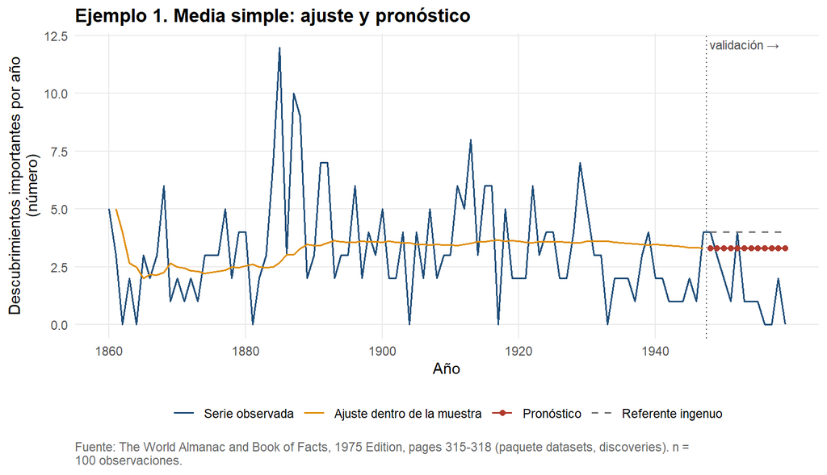

```r
.grafico_pronostico(d, fit$yhat, pron, ref, "Ejemplo 1. Media simple: ajuste y pronóstico")
```

## 3.7 Conclusión

Se utilizó la media simple sobre los 88 años de estimación, obteniendo un nivel promedio de 3,3068 descubrimientos por año. En la validación, el MASE fue 0,9192 frente a 1,1365 del pronóstico ingenuo y el MSE se redujo en 37,03 %, por lo que la media simple tuvo un mejor comportamiento que el ingenuo en este caso.

Las pruebas de los errores muestran que no hay un sesgo importante, ya que el valor p de la prueba t fue 0,846. Tampoco se encontró autocorrelación conjunta significativa con Ljung–Box. Sin embargo, Durbin–Watson sí detectó autocorrelación positiva de orden uno y la prueba de Jarque–Bera rechazó la normalidad.

En general, el método funciona razonablemente bien porque la serie no presenta una tendencia marcada. Aun así, los errores muestran que la serie tiene algo de dependencia que la media simple no alcanza a aprovechar.

## 3.8 Recomendación

Este pronóstico puede ser útil para tener una idea general del número esperado de descubrimientos por año, especialmente cuando no se necesita predecir con mucha precisión un año específico. En la validación obtuvo un MASE de 0,9192, por lo que tuvo un mejor resultado que el ingenuo.

El principal problema es que el nivel de la serie parece estar disminuyendo. El pronóstico queda fijo en 3,31, pero en 10 de los 12 años de validación terminó sobrestimando el número de descubrimientos. Por eso, si la disminución del nivel continúa, sería más conveniente utilizar un método que dé mayor peso a los datos recientes.

# 4 Ejemplo 2. Media móvil sobre `Nile`

## 4.1 Descripción de la serie

```r
x <- Nile
d <- leer_serie(x,
                fuente = "Durbin J, Koopman SJ (2001). Time Series Analysis by State Space Methods. Oxford University Press (paquete datasets, Nile)",
                unidad = "Caudal anual del Nilo en Asuán (10^8 m^3)")
descripcion(x, "Nile", d)
```

| Campo | Valor |
| --- | --- |
| Nombre en R | Nile |
| Fuente (help) | Durbin J, Koopman SJ (2001). Time Series Analysis by State Space Methods. Oxford University Press (paquete datasets, Nile) |
| Unidad | Caudal anual del Nilo en Asuán (10^8 m^3) |
| Frecuencia | 1 |
| Inicio (año, período) | 1871, 1 |
| Fin (año, período) | 1970, 1 |
| Rango de fechas | 1871-01-01 a 1970-01-01 |
| Observaciones | 100 |

La serie mide el caudal anual del Nilo en Asuán. La documentación de `help(Nile)` la describe «con cambio de nivel aparente cerca de 1898».

## 4.2 Patrón de la serie

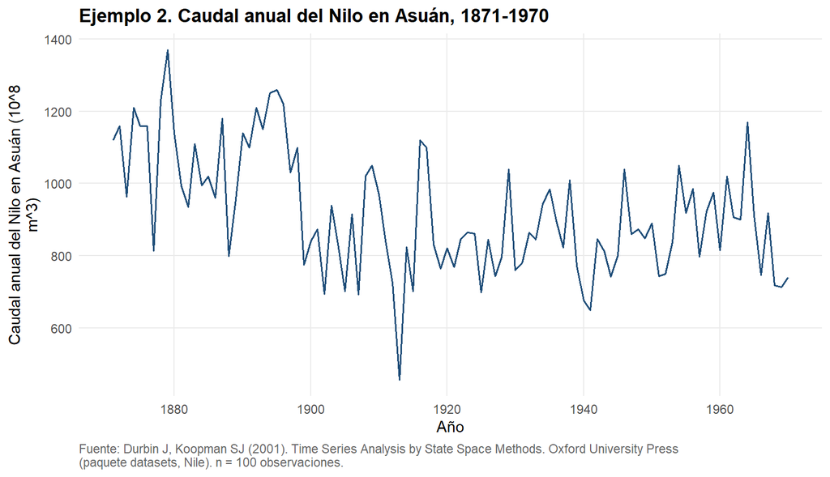

```r
graficar_serie(d, "Ejemplo 2. Caudal anual del Nilo en Asuán, 1871-1970")
```

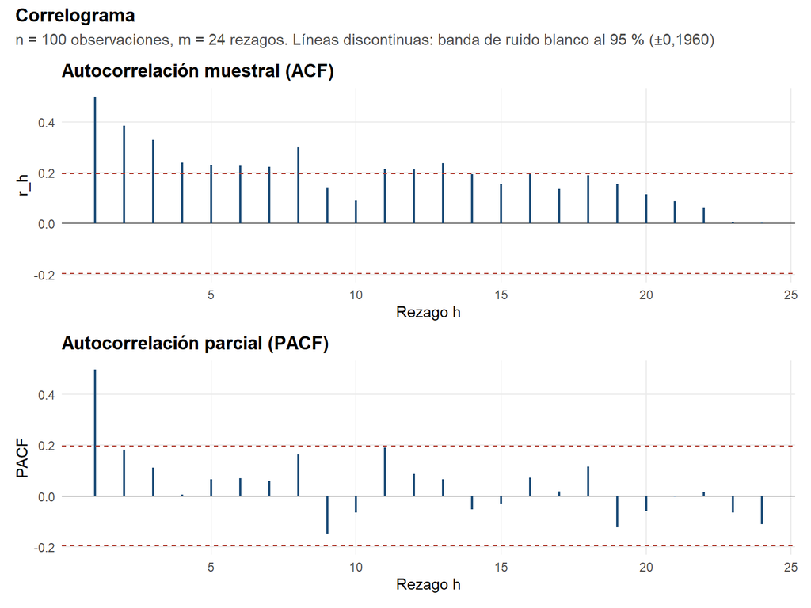

```r
cg <- correlograma(d)
cg$grafico
```

```r
n_total <- nrow(d)
r_1 <- .contraste_rh(cg$acf, n_total, 1)
pp(r_1, paste0("La autocorrelación en el primer rezago fue ", n4(cg$acf[1]), ", muy por encima de la banda de ±", n4(cg$banda),
               ". Por lo tanto, se rechaza la hipótesis de independencia. Esto muestra que el caudal de un año tiene bastante ",
               "relación con el del año anterior, por lo que utilizar información reciente para pronosticar tiene sentido."))
```

**Contraste individual de la autocorrelación en el rezago h = 1** (n = 100)

1. **Hipótesis.** $H_0:\ \rho_{1} = 0$; $H_1:\ \rho_{1} \neq 0$.
2. **Estadístico y distribución bajo $H_0$.** $T^* = \dfrac{r_h}{\sqrt{1/n}} = \sqrt{n}\, r_h\ \overset{H_0}{\approx}\ N(0,1)$.
3. **Región de rechazo al 5 %.** $|T^*| > z_{0{,}975} = 1,9600$, es decir $|r_{1}| > 0,1960$.
4. **Valor observado.** estadístico observado = 4,9841; valor p < 0,001.
5. **Decisión.** Se rechaza $H_0$ (nivel de significancia del 5 %).
6. **Lectura.** La autocorrelación en el primer rezago fue 0,4984, muy por encima de la banda de ±0,1960. Por lo tanto, se rechaza la hipótesis de independencia. Esto muestra que el caudal de un año tiene bastante relación con el del año anterior, por lo que utilizar información reciente para pronosticar tiene sentido.

```r
h_9 <- which(abs(cg$acf) < cg$banda)[1]
r_9 <- .contraste_rh(cg$acf, n_total, h_9)
pp(r_9, paste0("En el rezago ", h_9, " la autocorrelación fue ", n4(cg$acf[h_9]), " y quedó dentro de la banda de ±",
               n4(cg$banda), ". Esto indica que la memoria de la serie se va perdiendo después de aproximadamente ", h_9 - 1,
               " años, aunque no de forma limpia: los rezagos ", paste(setdiff(which(abs(cg$acf) > cg$banda), seq_len(h_9)), collapse = ", "),
               " vuelven a salir de la banda. No parece tratarse de una tendencia permanente, sino de un nivel que cambia poco a poco."))
```

**Contraste individual de la autocorrelación en el rezago h = 9** (n = 100)

1. **Hipótesis.** $H_0:\ \rho_{9} = 0$; $H_1:\ \rho_{9} \neq 0$.
2. **Estadístico y distribución bajo $H_0$.** $T^* = \dfrac{r_h}{\sqrt{1/n}} = \sqrt{n}\, r_h\ \overset{H_0}{\approx}\ N(0,1)$.
3. **Región de rechazo al 5 %.** $|T^*| > z_{0{,}975} = 1,9600$, es decir $|r_{9}| > 0,1960$.
4. **Valor observado.** estadístico observado = 1,4174; valor p = 0,156.
5. **Decisión.** No se rechaza $H_0$ (nivel de significancia del 5 %).
6. **Lectura.** En el rezago 9 la autocorrelación fue 0,1417 y quedó dentro de la banda de ±0,1960. Esto indica que la memoria de la serie se va perdiendo después de aproximadamente 8 años, aunque no de forma limpia: los rezagos 11, 12, 13 vuelven a salir de la banda. No parece tratarse de una tendencia permanente, sino de un nivel que cambia poco a poco.

```r
lb0 <- ljung_box(cg$acf, n_total, cg$m, 0)
pp(lb0, paste0("El valor p fue ", pv(lb0$valor_p), ", por lo que se rechaza que las primeras ", cg$m, " autocorrelaciones ",
               "sean todas cero. La serie tiene una estructura clara y, por lo tanto, existe información en los datos que puede ",
               "ser aprovechada para pronosticar."))
```

**Prueba de Ljung–Box** (n = 100)

1. **Hipótesis.** $H_0:\ \rho_1 = \rho_2 = \cdots = \rho_m = 0$; $H_1:\ \exists\, h \le m$ con $\rho_h \neq 0$.
2. **Estadístico y distribución bajo $H_0$.** $Q_m = T(T+2)\sum_{h=1}^{m} \dfrac{r_h^2}{T-h}\ \overset{H_0}{\sim}\ \chi^2_{m-p}$; $m = 24$, $p = 0$, luego los grados de libertad son $m - p = 24$.
3. **Región de rechazo al 5 %.** $Q_m > \chi^2_{0{,}95;\,24} = 36,4150$.
4. **Valor observado.** estadístico observado = 130,1800; valor p < 0,001.
5. **Decisión.** Se rechaza $H_0$ (nivel de significancia del 5 %).
6. **Lectura.** El valor p fue < 0,001, por lo que se rechaza que las primeras 24 autocorrelaciones sean todas cero. La serie tiene una estructura clara y, por lo tanto, existe información en los datos que puede ser aprovechada para pronosticar.

```r
antes <- mean(d$y[d$fecha < as.Date("1899-01-01")]); despues <- mean(d$y[d$fecha >= as.Date("1899-01-01")])
```

**Lectura del patrón.** La serie del caudal del Nilo no presenta una tendencia sostenida, pero sí muestra un cambio importante de nivel alrededor de 1898. El promedio pasa de 1097,75 antes de 1899 a 849,97 después, lo que representa una disminución de 22,57 %.

Esto hace que una media móvil tenga sentido, porque permite trabajar con un nivel que puede ir cambiando y, al usar los datos más recientes, puede adaptarse mejor a ese cambio.

## 4.3 Partición

```r
h <- min(12, floor(0.2 * n_total)); T_est <- n_total - h
est <- d[seq_len(T_est), ]; val <- d[T_est + seq_len(h), ]
```

Con $T = 100$ y $h = 12$, el tramo de estimación va de 1871 a 1958 ($T_{est} = 88$) y el de validación de 1959 a 1970.

## 4.4 Optimización de la ventana

La ventana $k$ se elige con `optimizar()` sobre $k = 2, \dots, 12$, minimizando el MSE de un paso dentro del tramo de estimación y con origen común en $t = 13$, el primer período en que la ventana de 12 ya pronostica.

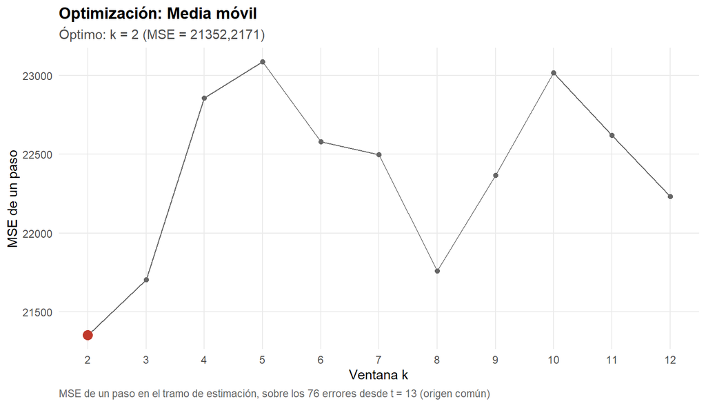

```r
opt <- optimizar(est$y, "mm")
opt$grafico
```

```r
tab(opt$rejilla, 2)
```

| k | mse |
| --- | --- |
| 2 | 21352,22 |
| 3 | 21706,63 |
| 4 | 22856,91 |
| 5 | 23087,05 |
| 6 | 22579,04 |
| 7 | 22497,75 |
| 8 | 21760,87 |
| 9 | 22365,83 |
| 10 | 23018,65 |
| 11 | 22621,97 |
| 12 | 22233,49 |

Al probar las diferentes ventanas, el menor MSE (21352,2171, calculado sobre 76 errores desde $t =$ 13) se obtuvo con $k =$ 2. Como este resultado está en el límite inferior de la rejilla (TRUE), la serie parece necesitar reaccionar bastante a los datos más recientes.

Además, las diferencias entre las ventanas no son muy grandes, ya que el MSE solo cambia 8,12 % entre la mejor y la peor. Por eso, aumentar mucho la ventana no genera una mejora importante. Con $k =$ 2 el método termina siendo bastante parecido al pronóstico ingenuo, que utiliza únicamente el último dato.

## 4.5 Ajuste y medidas

```r
fit <- ajustar_mm(est$y, opt$optimo$k)
pron <- fit$pronosticar(h)
ref <- rep(est$y[T_est], h)                       # ingenuo: el último valor observado
m_in <- .medir(est$y, fit$yhat, est$y)            # un paso, dentro del tramo de estimación
m_val <- .medir(val$y, pron, est$y)               # h pronósticos sobre el tramo de validación
m_ref <- .medir(val$y, ref, est$y)                # el ingenuo, mismo tramo y mismo h
tab(.tabla_medidas(m_in, m_val, m_ref, "Ingenuo"))
```

| caso | N | MSE | MAD | MAPE | MASE |
| --- | --- | --- | --- | --- | --- |
| Método, un paso (estimación) | 86 | 24349,85 | 125,3895 | 14,2240 | 0,9438 |
| Método, h pronósticos (validación) | 12 | 17984,00 | 112,5000 | 12,7476 | 0,8467 |
| Ingenuo, h pronósticos (validación) | 12 | 19685,00 | 111,0000 | 13,4537 | 0,8355 |

La media móvil no supera al ingenuo en MASE, ya que obtuvo 0,8467 frente a 0,8355. La diferencia es pequeña y corresponde a un error absoluto medio de 112,50 frente a 111,00.

En cambio, sí mejora el MSE, pasando de 19685,00 a 17984,00. Esto indica que la media móvil puede reducir algunos errores grandes, aunque los errores típicos no mejoran frente al ingenuo.

En general, la diferencia es pequeña y con solo 12 datos de validación no sería correcto afirmar que uno de los dos métodos es claramente superior.

## 4.6 Validación de los errores de un paso

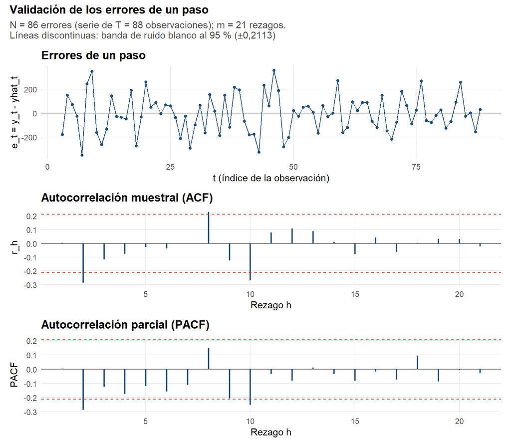

```r
cot <- .cotas("ej02", sum(!is.na(fit$errores)))
ve <- validar_errores(fit$errores, fit$n_param, T_est, cot$dL, cot$dU)
ve$grafico
```

Son $N = 86$ errores de un paso ($k = 2$ deja sin pronóstico a los dos primeros años), con $m = 21$ rezagos y banda de ±0,2113, calculada sobre $N$.

```r
fuera_e <- which(abs(ve$correlograma$acf) > ve$correlograma$banda)
pp(ve$t_media, paste0("El error medio fue ", n4(mean(ve$e)), " y el valor p fue ", pv(ve$t_media$valor_p),
                      ". Como no se rechaza la hipótesis de media cero, no hay evidencia de que la media móvil tenga un sesgo ",
                      "sistemático dentro de la muestra."))
```

**Prueba t de media cero de los errores** (n = 86)

1. **Hipótesis.** $H_0:\ \mu_e = 0$; $H_1:\ \mu_e \neq 0$.
2. **Estadístico y distribución bajo $H_0$.** $t = \dfrac{\bar{e}}{s_e/\sqrt{N}}\ \overset{H_0}{\sim}\ t_{N-1}$; grados de libertad: $85$.
3. **Región de rechazo al 5 %.** $|t| > t_{0{,}975;\,85} = 1,9883$.
4. **Valor observado.** estadístico observado = -0,2739; valor p = 0,785.
5. **Decisión.** No se rechaza $H_0$ (nivel de significancia del 5 %).
6. **Lectura.** El error medio fue -4,6337 y el valor p fue 0,785. Como no se rechaza la hipótesis de media cero, no hay evidencia de que la media móvil tenga un sesgo sistemático dentro de la muestra.

```r
pp(ve$ljung_box, paste0("El valor p fue ", pv(ve$ljung_box$valor_p), ", por lo que no se rechaza que los errores sean ",
                        "incorrelacionados en conjunto. Aunque el rezago 2 queda por fuera de la banda (r_2 = ",
                        n4(ve$correlograma$acf[2]), "), esto puede explicarse por la propia forma en que se construye una media ",
                        "móvil de dos datos: el dato de un año entra con peso 1 en su propio error y con peso −1/2 en el error de dos ",
                        "años después, lo que induce una correlación negativa en el rezago 2 (−1/3 si la serie fuera ruido blanco ",
                        "alrededor de un nivel). También salen de la banda los rezagos ",
                        paste(setdiff(fuera_e, 2), collapse = " y "), ", pero con m = ", ve$correlograma$m,
                        " rezagos se esperarían alrededor de ", round(0.05 * ve$correlograma$m), " salida por azar. Por lo tanto, ",
                        "no hay evidencia suficiente para decir que los errores tengan una estructura que el método esté ",
                        "dejando sin modelar."))
```

**Prueba de Ljung–Box sobre los errores** (n = 86)

1. **Hipótesis.** $H_0:\ \rho_1 = \rho_2 = \cdots = \rho_m = 0$; $H_1:\ \exists\, h \le m$ con $\rho_h \neq 0$.
2. **Estadístico y distribución bajo $H_0$.** $Q_m = T(T+2)\sum_{h=1}^{m} \dfrac{r_h^2}{T-h}\ \overset{H_0}{\sim}\ \chi^2_{m-p}$; $m = 21$, $p = 1$, luego los grados de libertad son $m - p = 20$.
3. **Región de rechazo al 5 %.** $Q_m > \chi^2_{0{,}95;\,20} = 31,4104$.
4. **Valor observado.** estadístico observado = 27,3837; valor p = 0,125.
5. **Decisión.** No se rechaza $H_0$ (nivel de significancia del 5 %).
6. **Lectura.** El valor p fue 0,125, por lo que no se rechaza que los errores sean incorrelacionados en conjunto. Aunque el rezago 2 queda por fuera de la banda (r_2 = -0,2858), esto puede explicarse por la propia forma en que se construye una media móvil de dos datos: el dato de un año entra con peso 1 en su propio error y con peso −1/2 en el error de dos años después, lo que induce una correlación negativa en el rezago 2 (−1/3 si la serie fuera ruido blanco alrededor de un nivel). También salen de la banda los rezagos 8 y 10, pero con m = 21 rezagos se esperarían alrededor de 1 salida por azar. Por lo tanto, no hay evidencia suficiente para decir que los errores tengan una estructura que el método esté dejando sin modelar.

```r
pp(ve$jarque_bera, paste0("El valor p fue ", pv(ve$jarque_bera$valor_p), ", por lo que no se rechaza la normalidad de los ",
                          "errores. Además, la asimetría (", n4(ve$jarque_bera$A), ") y la curtosis (", n4(ve$jarque_bera$K),
                          ") están relativamente cerca de los valores esperados para una distribución normal (0 y 3). Esto ",
                          "permite considerar razonables las pruebas realizadas sobre los errores."))
```

**Prueba de Jarque–Bera** (n = 86)

1. **Hipótesis.** $H_0:\ A = 0\ \text{y}\ K = 3$ (errores normales); $H_1:\ A \neq 0\ \text{o}\ K \neq 3$.
2. **Estadístico y distribución bajo $H_0$.** $JB = \dfrac{N}{6}\left[A^2 + \dfrac{(K-3)^2}{4}\right]\ \overset{H_0}{\sim}\ \chi^2_2$, con $A = m_3/m_2^{3/2}$ la asimetría y $K = m_4/m_2^2$ la curtosis muestrales; grados de libertad: $2$.
3. **Región de rechazo al 5 %.** $JB > \chi^2_{0{,}95;\,2} = 5,9915$.
4. **Valor observado.** estadístico observado = 0,7866; valor p = 0,675.
5. **Decisión.** No se rechaza $H_0$ (nivel de significancia del 5 %).
6. **Lectura.** El valor p fue 0,675, por lo que no se rechaza la normalidad de los errores. Además, la asimetría (0,0987) y la curtosis (2,5751) están relativamente cerca de los valores esperados para una distribución normal (0 y 3). Esto permite considerar razonables las pruebas realizadas sobre los errores.

```r
pp(ve$durbin_watson, paste0("El estadístico fue ", n4(ve$durbin_watson$estadistico), " y quedó por encima de d_U = ", n2(cot$dU),
                            ". Por lo tanto, no se rechaza la ausencia de autocorrelación positiva de orden uno. Esto coincide con ",
                            "r_1 = ", n4(ve$correlograma$acf[1]), ", que prácticamente es cero."))
```

**Prueba de Durbin–Watson** (n = 86)

1. **Hipótesis.** $H_0:\ \rho = 0$ (sin autocorrelación de orden 1); $H_1:\ \rho > 0$.
2. **Estadístico y distribución bajo $H_0$.** $d = \dfrac{\sum_{t=2}^{N}(e_t - e_{t-1})^2}{\sum_{t=1}^{N} e_t^2} \approx 2(1 - r_1)$; sin distribución exacta bajo $H_0$, se decide con las cotas $d_L$ y $d_U$.
3. **Región de rechazo al 5 %.** Se rechaza $H_0$ si $d < d_L = 1,6300$; no se rechaza si $d > d_U = 1,6700$; inconclusa si $d_L \le d \le d_U$.
4. **Valor observado.** estadístico observado = 1,9737; sin valor p exacto (se decide con las cotas tabuladas).
5. **Decisión.** No se rechaza $H_0$ (nivel de significancia del 5 %).
6. **Lectura.** El estadístico fue 1,9737 y quedó por encima de d_U = 1,67. Por lo tanto, no se rechaza la ausencia de autocorrelación positiva de orden uno. Esto coincide con r_1 = 0,0049, que prácticamente es cero.

## 4.7 Gráfico final

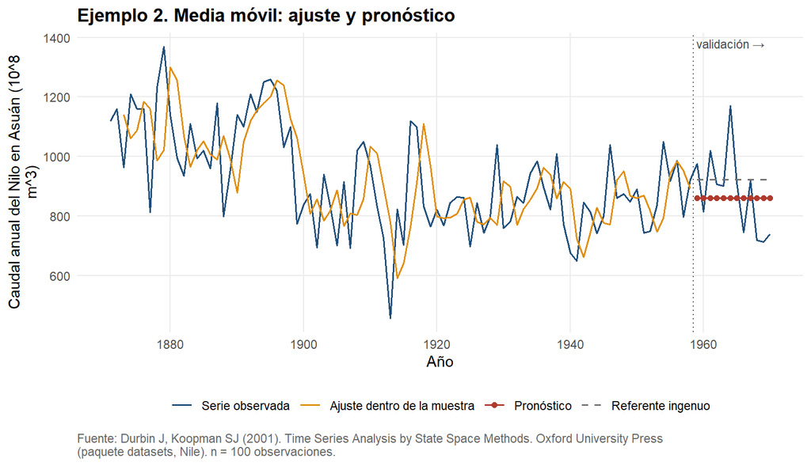

```r
.grafico_pronostico(d, fit$yhat, pron, ref, "Ejemplo 2. Media móvil: ajuste y pronóstico")
```

## 4.8 Conclusión

Se ajustó una media móvil con $k =$ 2, que fue la ventana que produjo el menor MSE dentro de la estimación. En la validación obtuvo un MASE de 0,8467 frente a 0,8355 del ingenuo. Por lo tanto, no lo supera en MASE, aunque sí consigue reducir el MSE de 19685,00 a 17984,00.

Esto muestra que el método puede ayudar a reducir algunos errores grandes, pero la mejora no es suficiente para decir que sea claramente mejor que repetir el último dato. Además, $k =$ 2 hace que la media móvil sea muy parecida al pronóstico ingenuo.

Por otro lado, las pruebas conjuntas sobre los errores fueron favorables: no se encontró sesgo (valor p 0,785), autocorrelación conjunta (Ljung–Box, valor p 0,125), problemas de normalidad (Jarque–Bera, valor p 0,675) ni autocorrelación de orden uno (Durbin–Watson 1,9737 frente a $d_U =$ 1,67). En el correlograma de los errores salen de la banda los rezagos 2, 8, 10, el 2 por la construcción de una media móvil de dos datos y los demás en un número compatible con las falsas alarmas esperadas. El método funciona de manera razonable, pero en esta serie no aporta una mejora clara frente al ingenuo.

## 4.9 Recomendación

La media móvil puede servir para tener una estimación general del caudal del año siguiente, especialmente como una primera aproximación. Sin embargo, su precisión es limitada: en los 12 años de validación el error absoluto máximo fue de 310,00 y el error absoluto medio fue de 112,50.

Además, el método no consiguió mejorar de forma clara al ingenuo. Para reaccionar mejor a los cambios recientes sería preferible utilizar un método que dé pesos diferentes a los datos, como el suavizamiento exponencial simple.

# 5 Ejemplo 3. Suavizamiento exponencial simple sobre `Nile`

Se utiliza nuevamente la serie del Nilo (el enunciado permite hasta dos ejemplos por serie) para poder comparar directamente el suavizamiento exponencial simple con la media móvil del ejemplo anterior. De esta manera, los dos métodos se evalúan con los mismos datos y el mismo período de validación. La serie `LakeHuron`, que era la otra candidata, se descartó tras comprobar lo siguiente:

```r
lh <- as.numeric(LakeHuron); lh_est <- lh[seq_len(length(lh) - min(12, floor(0.2 * length(lh))))]
opt_lh <- optimizar(lh_est, "ses")
r1_lh <- correlograma(lh)$acf[1]
```

Su autocorrelación en el primer rezago es muy alta, 0,8319, y el método termina escogiendo $\alpha =$ 0,98, en el borde superior de la rejilla, que prácticamente se comporta como el pronóstico ingenuo.

## 5.1 Descripción de la serie

```r
x <- Nile
d <- leer_serie(x,
                fuente = "Durbin J, Koopman SJ (2001). Time Series Analysis by State Space Methods. Oxford University Press (paquete datasets, Nile)",
                unidad = "Caudal anual del Nilo en Asuán (10^8 m^3)")
descripcion(x, "Nile", d)
```

| Campo | Valor |
| --- | --- |
| Nombre en R | Nile |
| Fuente (help) | Durbin J, Koopman SJ (2001). Time Series Analysis by State Space Methods. Oxford University Press (paquete datasets, Nile) |
| Unidad | Caudal anual del Nilo en Asuán (10^8 m^3) |
| Frecuencia | 1 |
| Inicio (año, período) | 1871, 1 |
| Fin (año, período) | 1970, 1 |
| Rango de fechas | 1871-01-01 a 1970-01-01 |
| Observaciones | 100 |

## 5.2 Patrón de la serie

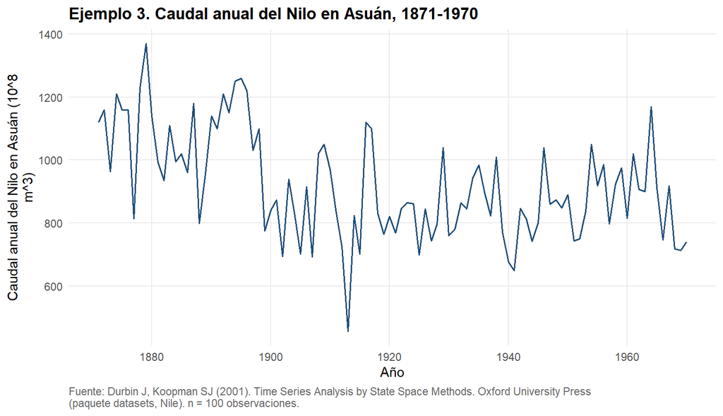

```r
graficar_serie(d, "Ejemplo 3. Caudal anual del Nilo en Asuán, 1871-1970")
```

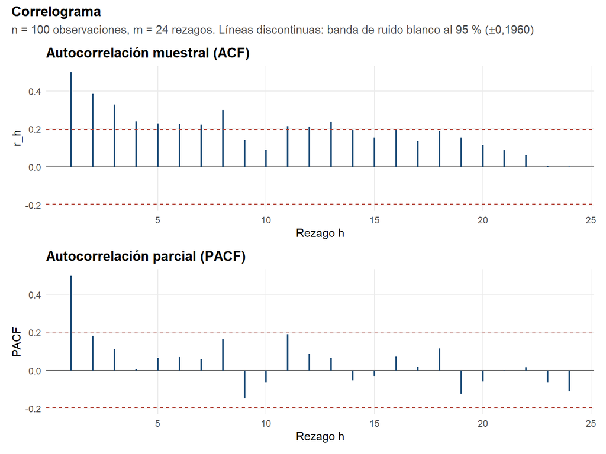

```r
cg <- correlograma(d)
cg$grafico
```

```r
n_total <- nrow(d)
r_1 <- .contraste_rh(cg$acf, n_total, 1)
pp(r_1, paste0("La autocorrelación fue ", n4(cg$acf[1]), " y quedó por encima de la banda de ±", n4(cg$banda),
               ", por lo que se rechaza la independencia en el primer rezago. Esto significa que el caudal del año anterior ",
               "contiene información útil para predecir el siguiente."))
```

**Contraste individual de la autocorrelación en el rezago h = 1** (n = 100)

1. **Hipótesis.** $H_0:\ \rho_{1} = 0$; $H_1:\ \rho_{1} \neq 0$.
2. **Estadístico y distribución bajo $H_0$.** $T^* = \dfrac{r_h}{\sqrt{1/n}} = \sqrt{n}\, r_h\ \overset{H_0}{\approx}\ N(0,1)$.
3. **Región de rechazo al 5 %.** $|T^*| > z_{0{,}975} = 1,9600$, es decir $|r_{1}| > 0,1960$.
4. **Valor observado.** estadístico observado = 4,9841; valor p < 0,001.
5. **Decisión.** Se rechaza $H_0$ (nivel de significancia del 5 %).
6. **Lectura.** La autocorrelación fue 0,4984 y quedó por encima de la banda de ±0,1960, por lo que se rechaza la independencia en el primer rezago. Esto significa que el caudal del año anterior contiene información útil para predecir el siguiente.

```r
r_2 <- .contraste_rh(cg$acf, n_total, 2)
pp(r_2, paste0("La autocorrelación en el segundo rezago fue ", n4(cg$acf[2]), " y también resultó significativa. Además, ",
               "disminuye de manera gradual respecto al primer rezago. Esto muestra que la memoria de la serie no desaparece de ",
               "inmediato, sino que se va reduciendo poco a poco, que es justamente el tipo de comportamiento que puede ",
               "aprovechar el suavizamiento exponencial."))
```

**Contraste individual de la autocorrelación en el rezago h = 2** (n = 100)

1. **Hipótesis.** $H_0:\ \rho_{2} = 0$; $H_1:\ \rho_{2} \neq 0$.
2. **Estadístico y distribución bajo $H_0$.** $T^* = \dfrac{r_h}{\sqrt{1/n}} = \sqrt{n}\, r_h\ \overset{H_0}{\approx}\ N(0,1)$.
3. **Región de rechazo al 5 %.** $|T^*| > z_{0{,}975} = 1,9600$, es decir $|r_{2}| > 0,1960$.
4. **Valor observado.** estadístico observado = 3,8458; valor p < 0,001.
5. **Decisión.** Se rechaza $H_0$ (nivel de significancia del 5 %).
6. **Lectura.** La autocorrelación en el segundo rezago fue 0,3846 y también resultó significativa. Además, disminuye de manera gradual respecto al primer rezago. Esto muestra que la memoria de la serie no desaparece de inmediato, sino que se va reduciendo poco a poco, que es justamente el tipo de comportamiento que puede aprovechar el suavizamiento exponencial.

```r
lb0 <- ljung_box(cg$acf, n_total, cg$m, 0)
pp(lb0, paste0("El valor p fue ", pv(lb0$valor_p), ", por lo que se rechaza que la serie sea ruido blanco. Hay una ",
               "estructura de dependencia clara que puede ser aprovechada por un método de pronóstico."))
```

**Prueba de Ljung–Box** (n = 100)

1. **Hipótesis.** $H_0:\ \rho_1 = \rho_2 = \cdots = \rho_m = 0$; $H_1:\ \exists\, h \le m$ con $\rho_h \neq 0$.
2. **Estadístico y distribución bajo $H_0$.** $Q_m = T(T+2)\sum_{h=1}^{m} \dfrac{r_h^2}{T-h}\ \overset{H_0}{\sim}\ \chi^2_{m-p}$; $m = 24$, $p = 0$, luego los grados de libertad son $m - p = 24$.
3. **Región de rechazo al 5 %.** $Q_m > \chi^2_{0{,}95;\,24} = 36,4150$.
4. **Valor observado.** estadístico observado = 130,1800; valor p < 0,001.
5. **Decisión.** Se rechaza $H_0$ (nivel de significancia del 5 %).
6. **Lectura.** El valor p fue < 0,001, por lo que se rechaza que la serie sea ruido blanco. Hay una estructura de dependencia clara que puede ser aprovechada por un método de pronóstico.

**Lectura del patrón.** La serie no presenta una tendencia sostenida, pero sí tiene un nivel que cambia con el tiempo. La autocorrelación positiva disminuye de forma gradual y el cambio de nivel alrededor de 1898 muestra que los datos recientes pueden ser más útiles que los antiguos.

Esto corresponde al supuesto del suavizamiento exponencial simple, ya que el método da mayor peso a los datos recientes, pero sin eliminar completamente la información más antigua.

## 5.3 Partición

```r
h <- min(12, floor(0.2 * n_total)); T_est <- n_total - h
est <- d[seq_len(T_est), ]; val <- d[T_est + seq_len(h), ]
```

Con $T = 100$ y $h = 12$, el tramo de estimación va de 1871 a 1958 ($T_{est} = 88$) y el de validación de 1959 a 1970.

## 5.4 Optimización de la constante

$\alpha$ se elige con `optimizar()` sobre $\alpha = 0{,}02, 0{,}04, \dots, 0{,}98$, minimizando el MSE de un paso dentro del tramo de estimación (origen común en $t = 2$, donde todas las constantes ya pronostican).

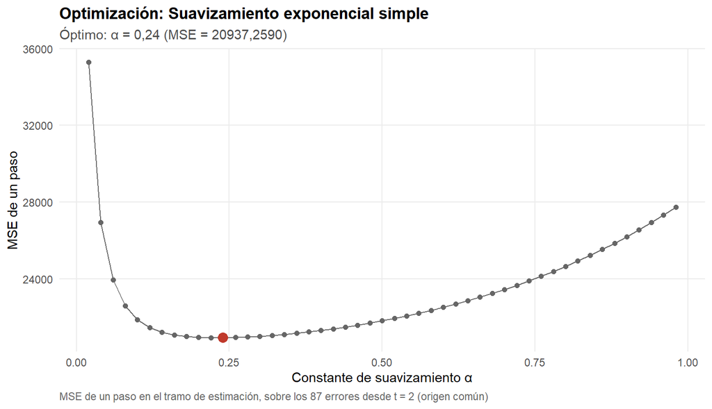

```r
opt <- optimizar(est$y, "ses")
opt$grafico
```

El valor que produjo el menor MSE fue $\alpha =$ 0,24, con un MSE de 20937,2590 (calculado sobre 87 errores). Como el valor está dentro de la rejilla y no en uno de los extremos (borde de la rejilla: FALSE), significa que el mejor resultado se obtiene con un equilibrio entre los datos recientes y los antiguos.

Un $\alpha$ muy pequeño reaccionaría poco a los cambios, mientras que uno cercano a 1 se comportaría casi como el ingenuo. En este caso, $\alpha =$ 0,24 muestra que ninguna de esas dos opciones extremas es la mejor.

## 5.5 Ajuste y medidas

```r
fit <- ajustar_ses(est$y, opt$optimo$alpha)
pron <- fit$pronosticar(h)
ref <- rep(est$y[T_est], h)                       # ingenuo: el último valor observado
m_in <- .medir(est$y, fit$yhat, est$y)            # un paso, dentro del tramo de estimación
m_val <- .medir(val$y, pron, est$y)               # h pronósticos sobre el tramo de validación
m_ref <- .medir(val$y, ref, est$y)                # el ingenuo, mismo tramo y mismo h
tab(.tabla_medidas(m_in, m_val, m_ref, "Ingenuo"))
```

| caso | N | MSE | MAD | MAPE | MASE |
| --- | --- | --- | --- | --- | --- |
| Método, un paso (estimación) | 87 | 20937,26 | 113,6056 | 13,0893 | 0,8551 |
| Método, h pronósticos (validación) | 12 | 17864,46 | 107,1168 | 12,6004 | 0,8062 |
| Ingenuo, h pronósticos (validación) | 12 | 19685,00 | 111,0000 | 13,4537 | 0,8355 |

```r
# La media móvil del ejemplo 2 sobre los mismos datos, para compararla en el mismo tramo de validación
mm_ej2 <- ajustar_mm(est$y, optimizar(est$y, "mm")$optimo$k)
m_mm <- .medir(val$y, mm_ej2$pronosticar(h), est$y)
```

En la validación, el suavizamiento exponencial simple mejora al ingenuo en las tres medidas. El MSE baja de 19685,00 a 17864,46, el MAD de 111,00 a 107,12 y el MASE de 0,8355 a 0,8062.

También mejora ligeramente a la media móvil del ejemplo anterior, que obtuvo un MASE de 0,8467. La diferencia no es muy grande, pero sugiere que dar mayor peso a los datos recientes funciona un poco mejor en esta serie, aunque con solo 12 datos de validación no es una diferencia que un contraste formal separaría de la variabilidad de la serie (desviación estándar 169,23).

## 5.6 Validación de los errores de un paso

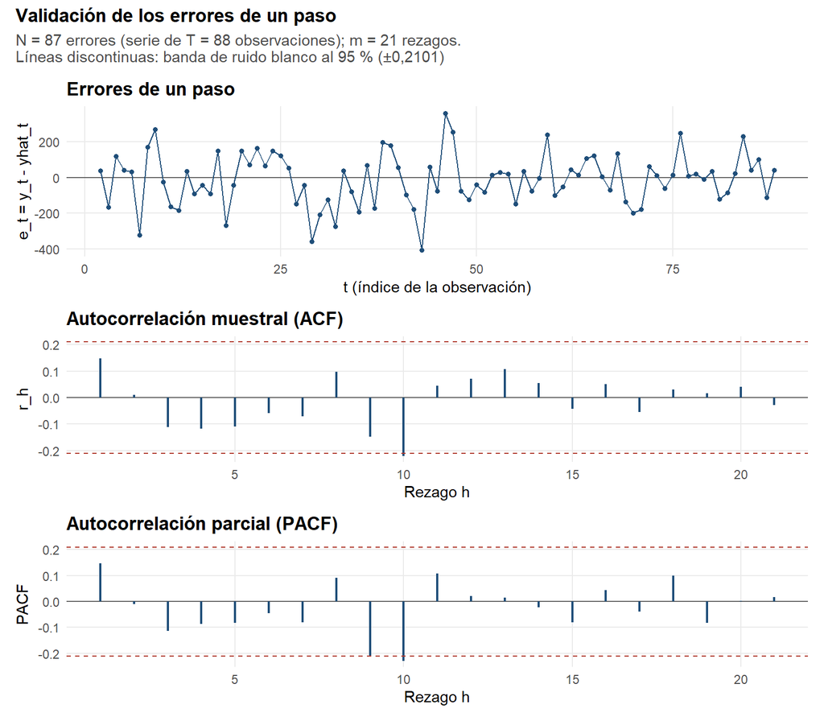

```r
cot <- .cotas("ej03", sum(!is.na(fit$errores)))
ve <- validar_errores(fit$errores, fit$n_param, T_est, cot$dL, cot$dU)
ve$grafico
```

Son $N = 87$ errores de un paso, con $m = 21$ rezagos y banda de ±0,2101, calculada sobre $N$.

```r
pp(ve$t_media, paste0("El error medio fue ", n4(mean(ve$e)), " y el valor p fue ", pv(ve$t_media$valor_p),
                      ". Como no se rechaza la hipótesis de media cero, no hay evidencia de que el método sobrestime o subestime ",
                      "sistemáticamente los valores."))
```

**Prueba t de media cero de los errores** (n = 87)

1. **Hipótesis.** $H_0:\ \mu_e = 0$; $H_1:\ \mu_e \neq 0$.
2. **Estadístico y distribución bajo $H_0$.** $t = \dfrac{\bar{e}}{s_e/\sqrt{N}}\ \overset{H_0}{\sim}\ t_{N-1}$; grados de libertad: $86$.
3. **Región de rechazo al 5 %.** $|t| > t_{0{,}975;\,86} = 1,9879$.
4. **Valor observado.** estadístico observado = -0,7009; valor p = 0,485.
5. **Decisión.** No se rechaza $H_0$ (nivel de significancia del 5 %).
6. **Lectura.** El error medio fue -10,9052 y el valor p fue 0,485. Como no se rechaza la hipótesis de media cero, no hay evidencia de que el método sobrestime o subestime sistemáticamente los valores.

```r
pp(ve$ljung_box, paste0("El valor p fue ", pv(ve$ljung_box$valor_p), ", por lo que no se rechaza que los errores sean ",
                        "incorrelacionados. Además, solo ", sum(abs(ve$correlograma$acf) > ve$correlograma$banda), " de los ",
                        ve$correlograma$m, " rezagos quedó por fuera de la banda, algo que puede ocurrir simplemente por azar. ",
                        "Esto indica que el suavizamiento exponencial logró reducir la autocorrelación que estaba presente en la ",
                        "serie original (r_1 = ", n4(cg$acf[1]), " pasó a ", n4(ve$correlograma$acf[1]), " en los errores)."))
```

**Prueba de Ljung–Box sobre los errores** (n = 87)

1. **Hipótesis.** $H_0:\ \rho_1 = \rho_2 = \cdots = \rho_m = 0$; $H_1:\ \exists\, h \le m$ con $\rho_h \neq 0$.
2. **Estadístico y distribución bajo $H_0$.** $Q_m = T(T+2)\sum_{h=1}^{m} \dfrac{r_h^2}{T-h}\ \overset{H_0}{\sim}\ \chi^2_{m-p}$; $m = 21$, $p = 1$, luego los grados de libertad son $m - p = 20$.
3. **Región de rechazo al 5 %.** $Q_m > \chi^2_{0{,}95;\,20} = 31,4104$.
4. **Valor observado.** estadístico observado = 17,7572; valor p = 0,603.
5. **Decisión.** No se rechaza $H_0$ (nivel de significancia del 5 %).
6. **Lectura.** El valor p fue 0,603, por lo que no se rechaza que los errores sean incorrelacionados. Además, solo 1 de los 21 rezagos quedó por fuera de la banda, algo que puede ocurrir simplemente por azar. Esto indica que el suavizamiento exponencial logró reducir la autocorrelación que estaba presente en la serie original (r_1 = 0,4984 pasó a 0,1470 en los errores).

```r
pp(ve$jarque_bera, paste0("La prueba obtuvo un valor p de ", pv(ve$jarque_bera$valor_p), ", por lo que no se rechaza la ",
                          "normalidad de los errores. La asimetría (", n4(ve$jarque_bera$A), ") y la curtosis (",
                          n4(ve$jarque_bera$K), ") están muy cerca de los valores esperados para una distribución normal (0 y 3)."))
```

**Prueba de Jarque–Bera** (n = 87)

1. **Hipótesis.** $H_0:\ A = 0\ \text{y}\ K = 3$ (errores normales); $H_1:\ A \neq 0\ \text{o}\ K \neq 3$.
2. **Estadístico y distribución bajo $H_0$.** $JB = \dfrac{N}{6}\left[A^2 + \dfrac{(K-3)^2}{4}\right]\ \overset{H_0}{\sim}\ \chi^2_2$, con $A = m_3/m_2^{3/2}$ la asimetría y $K = m_4/m_2^2$ la curtosis muestrales; grados de libertad: $2$.
3. **Región de rechazo al 5 %.** $JB > \chi^2_{0{,}95;\,2} = 5,9915$.
4. **Valor observado.** estadístico observado = 0,3304; valor p = 0,848.
5. **Decisión.** No se rechaza $H_0$ (nivel de significancia del 5 %).
6. **Lectura.** La prueba obtuvo un valor p de 0,848, por lo que no se rechaza la normalidad de los errores. La asimetría (-0,1327) y la curtosis (3,1441) están muy cerca de los valores esperados para una distribución normal (0 y 3).

```r
pp(ve$durbin_watson, paste0("El estadístico fue ", n4(ve$durbin_watson$estadistico), ", ligeramente por encima de d_U = ",
                            n2(cot$dU), ". Por lo tanto, no se rechaza la ausencia de autocorrelación positiva de orden uno. ",
                            "El resultado también es coherente con r_1 = ", n4(ve$correlograma$acf[1]),
                            ", que está dentro de la banda."))
```

**Prueba de Durbin–Watson** (n = 87)

1. **Hipótesis.** $H_0:\ \rho = 0$ (sin autocorrelación de orden 1); $H_1:\ \rho > 0$.
2. **Estadístico y distribución bajo $H_0$.** $d = \dfrac{\sum_{t=2}^{N}(e_t - e_{t-1})^2}{\sum_{t=1}^{N} e_t^2} \approx 2(1 - r_1)$; sin distribución exacta bajo $H_0$, se decide con las cotas $d_L$ y $d_U$.
3. **Región de rechazo al 5 %.** Se rechaza $H_0$ si $d < d_L = 1,6300$; no se rechaza si $d > d_U = 1,6700$; inconclusa si $d_L \le d \le d_U$.
4. **Valor observado.** estadístico observado = 1,6935; sin valor p exacto (se decide con las cotas tabuladas).
5. **Decisión.** No se rechaza $H_0$ (nivel de significancia del 5 %).
6. **Lectura.** El estadístico fue 1,6935, ligeramente por encima de d_U = 1,67. Por lo tanto, no se rechaza la ausencia de autocorrelación positiva de orden uno. El resultado también es coherente con r_1 = 0,1470, que está dentro de la banda.

## 5.7 Gráfico final

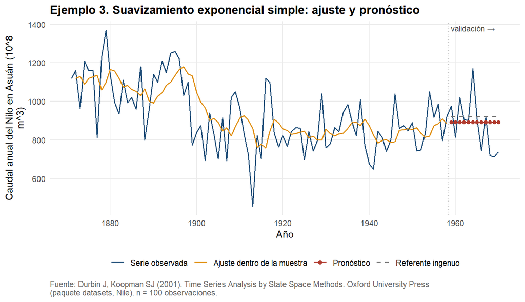

```r
.grafico_pronostico(d, fit$yhat, pron, ref, "Ejemplo 3. Suavizamiento exponencial simple: ajuste y pronóstico")
```

## 5.8 Conclusión

Se ajustó un suavizamiento exponencial simple con $\alpha =$ 0,24. En la validación obtuvo un MASE de 0,8062 frente a 0,8355 del ingenuo, además de menores valores de MSE y MAD. Por lo tanto, en esta serie el método consigue una mejora, aunque la diferencia es relativamente pequeña.

Las pruebas de los errores también dieron resultados favorables: no se encontró sesgo (valor p 0,485), autocorrelación conjunta (Ljung–Box, valor p 0,603), falta de normalidad (Jarque–Bera, valor p 0,848) ni autocorrelación de orden uno (Durbin–Watson 1,6935 frente a $d_U =$ 1,67). En comparación con la media móvil del ejemplo anterior, el suavizamiento exponencial obtiene un resultado ligeramente mejor (MASE 0,8062 contra 0,8467).

## 5.9 Recomendación

El método puede utilizarse para estimar el caudal de los próximos años, especialmente en horizontes cortos de uno a tres años. En la validación, el error absoluto máximo fue de 277,70 y el error absoluto medio fue de 107,12.

Sin embargo, el método produce una línea de pronóstico plana, por lo que no puede seguir cambios de nivel importantes como el ocurrido alrededor de 1898. Por esto, a horizontes más largos el pronóstico debe tomarse con mayor cuidado.

# 6 Ejemplo 4. Doble media móvil sobre `austres`

## 6.1 Descripción de la serie

```r
x <- austres
d <- leer_serie(x,
                fuente = "Brockwell PJ, Davis RA (1996). Introduction to Time Series and Forecasting. Springer (paquete datasets, austres)",
                unidad = "Residentes de Australia (miles)")
descripcion(x, "austres", d)
```

| Campo | Valor |
| --- | --- |
| Nombre en R | austres |
| Fuente (help) | Brockwell PJ, Davis RA (1996). Introduction to Time Series and Forecasting. Springer (paquete datasets, austres) |
| Unidad | Residentes de Australia (miles) |
| Frecuencia | 4 |
| Inicio (año, período) | 1971, 2 |
| Fin (año, período) | 1993, 2 |
| Rango de fechas | 1971-04-01 a 1993-04-01 |
| Observaciones | 89 |

La serie cuenta los residentes de Australia cada trimestre. Antes de realizar el análisis se verificó el rango directamente con los datos de R. Aunque la documentación indica un período diferente (`help(austres)` dice «from March 1971 to March 1994»), los datos realmente utilizados, verificados con `start()`, `end()` y `length()` en la tabla anterior, van de 1971-04-01 a 1993-04-01, con 89 observaciones. Por eso, el análisis se realizó usando el rango que aparece en los datos y no únicamente el que aparece en la documentación.

## 6.2 Patrón de la serie

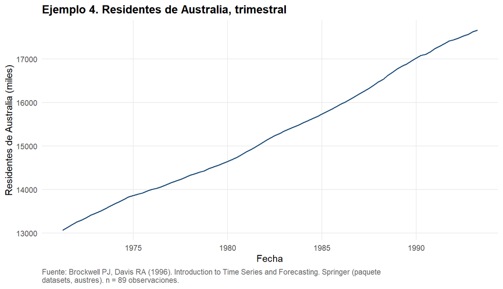

```r
graficar_serie(d, "Ejemplo 4. Residentes de Australia, trimestral")
```

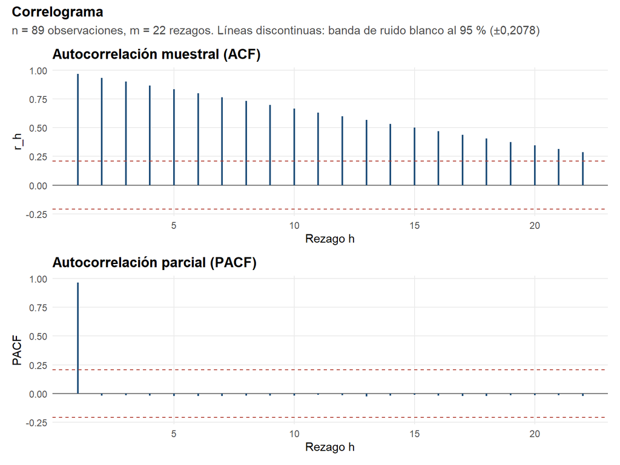

```r
cg <- correlograma(d)
cg$grafico
```

```r
n_total <- nrow(d)
r_1 <- .contraste_rh(cg$acf, n_total, 1)
pp(r_1, paste0("La autocorrelación del primer rezago fue ", n4(cg$acf[1]), ", muy cerca de 1 y bastante por encima de la banda de ±",
               n4(cg$banda), ". Esto muestra que cada trimestre está muy relacionado con el anterior, algo que es esperable en ",
               "una serie con una tendencia creciente."))
```

**Contraste individual de la autocorrelación en el rezago h = 1** (n = 89)

1. **Hipótesis.** $H_0:\ \rho_{1} = 0$; $H_1:\ \rho_{1} \neq 0$.
2. **Estadístico y distribución bajo $H_0$.** $T^* = \dfrac{r_h}{\sqrt{1/n}} = \sqrt{n}\, r_h\ \overset{H_0}{\approx}\ N(0,1)$.
3. **Región de rechazo al 5 %.** $|T^*| > z_{0{,}975} = 1,9600$, es decir $|r_{1}| > 0,2078$.
4. **Valor observado.** estadístico observado = 9,1188; valor p < 0,001.
5. **Decisión.** Se rechaza $H_0$ (nivel de significancia del 5 %).
6. **Lectura.** La autocorrelación del primer rezago fue 0,9666, muy cerca de 1 y bastante por encima de la banda de ±0,2078. Esto muestra que cada trimestre está muy relacionado con el anterior, algo que es esperable en una serie con una tendencia creciente.

```r
r_m <- .contraste_rh(cg$acf, n_total, cg$m)
pp(r_m, paste0("Incluso en el rezago ", cg$m, " la autocorrelación sigue siendo significativa, con un valor de ", n4(cg$acf[cg$m]),
               ". Además, las autocorrelaciones disminuyen lentamente y no llegan a cero. Este comportamiento es una señal clara ",
               "de tendencia, ya que una serie estacionaria normalmente perdería su autocorrelación después de pocos rezagos."))
```

**Contraste individual de la autocorrelación en el rezago h = 22** (n = 89)

1. **Hipótesis.** $H_0:\ \rho_{22} = 0$; $H_1:\ \rho_{22} \neq 0$.
2. **Estadístico y distribución bajo $H_0$.** $T^* = \dfrac{r_h}{\sqrt{1/n}} = \sqrt{n}\, r_h\ \overset{H_0}{\approx}\ N(0,1)$.
3. **Región de rechazo al 5 %.** $|T^*| > z_{0{,}975} = 1,9600$, es decir $|r_{22}| > 0,2078$.
4. **Valor observado.** estadístico observado = 2,6917; valor p = 0,007.
5. **Decisión.** Se rechaza $H_0$ (nivel de significancia del 5 %).
6. **Lectura.** Incluso en el rezago 22 la autocorrelación sigue siendo significativa, con un valor de 0,2853. Además, las autocorrelaciones disminuyen lentamente y no llegan a cero. Este comportamiento es una señal clara de tendencia, ya que una serie estacionaria normalmente perdería su autocorrelación después de pocos rezagos.

```r
lb0 <- ljung_box(cg$acf, n_total, cg$m, 0)
pp(lb0, paste0("El estadístico Ljung–Box fue ", n4(lb0$estadistico), " con un valor p ", pv(lb0$valor_p), ". Por lo tanto, se ",
               "rechaza que la serie sea ruido blanco. La estructura de la serie es muy fuerte y claramente puede aprovecharse ",
               "para pronosticar."))
```

**Prueba de Ljung–Box** (n = 89)

1. **Hipótesis.** $H_0:\ \rho_1 = \rho_2 = \cdots = \rho_m = 0$; $H_1:\ \exists\, h \le m$ con $\rho_h \neq 0$.
2. **Estadístico y distribución bajo $H_0$.** $Q_m = T(T+2)\sum_{h=1}^{m} \dfrac{r_h^2}{T-h}\ \overset{H_0}{\sim}\ \chi^2_{m-p}$; $m = 22$, $p = 0$, luego los grados de libertad son $m - p = 22$.
3. **Región de rechazo al 5 %.** $Q_m > \chi^2_{0{,}95;\,22} = 33,9244$.
4. **Valor observado.** estadístico observado = 938,9522; valor p < 0,001.
5. **Decisión.** Se rechaza $H_0$ (nivel de significancia del 5 %).
6. **Lectura.** El estadístico Ljung–Box fue 938,9522 con un valor p < 0,001. Por lo tanto, se rechaza que la serie sea ruido blanco. La estructura de la serie es muy fuerte y claramente puede aprovecharse para pronosticar.

**Lectura del patrón.** La serie muestra una tendencia creciente bastante clara. Una regresión lineal explica el 99,39 % de la variación y el crecimiento promedio es de 52,21 miles de habitantes por trimestre.

Aunque la serie parece casi una línea recta, la pendiente no es exactamente la misma durante todo el período. El crecimiento promedio pasa de 48,11 en la primera mitad a 56,30 en la segunda. Por eso, la doble media móvil tiene sentido, ya que permite ir actualizando la pendiente a medida que aparecen nuevos datos.

## 6.3 Partición

```r
h <- min(12, floor(0.2 * n_total)); T_est <- n_total - h
est <- d[seq_len(T_est), ]; val <- d[T_est + seq_len(h), ]
```

Con $T = 89$ y $h = 12$ (tres años), el tramo de estimación va de 1971-04-01 a 1990-04-01 ($T_{est} = 77$) y el de validación de 1990-07-01 a 1993-04-01.

## 6.4 Optimización de la ventana

La ventana $k$ se elige con `optimizar()` sobre $k = 2, \dots, 12$. La doble media móvil necesita $2k - 1$ datos antes de su primer pronóstico, así que el origen común es $t = 24$, el primero que la ventana de 12 puede pronosticar.

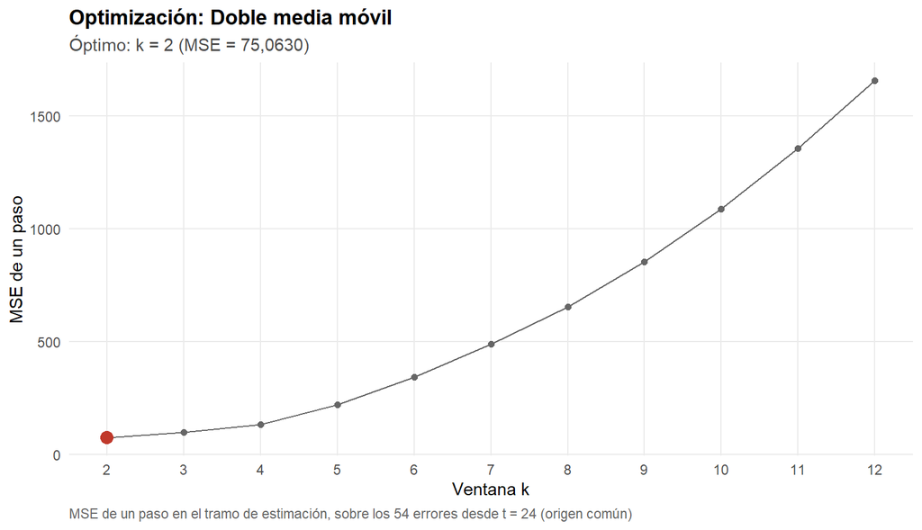

```r
opt <- optimizar(est$y, "dmm")
opt$grafico
```

```r
tab(opt$rejilla, 2)
```

| k | mse |
| --- | --- |
| 2 | 75,06 |
| 3 | 97,91 |
| 4 | 134,56 |
| 5 | 222,09 |
| 6 | 344,70 |
| 7 | 489,68 |
| 8 | 653,86 |
| 9 | 854,58 |
| 10 | 1088,54 |
| 11 | 1356,05 |
| 12 | 1657,42 |

El menor MSE (75,0630, calculado sobre 54 errores desde $t =$ 24) se obtuvo con $k =$ 2, que corresponde a la ventana más pequeña permitida por el método (con $k = 1$ el factor $2/(k-1)$ no está definido; borde de la rejilla: TRUE). Además, el MSE aumenta bastante cuando se utiliza una ventana más grande, hasta 22,08 veces el óptimo en $k =$ 12.

Esto tiene sentido porque la serie cambia de pendiente lentamente y una ventana larga incluiría información antigua que ya no representa tan bien el comportamiento reciente. En este caso, utilizar pocos datos permite que el método reaccione más rápido a los cambios.

## 6.5 Ajuste y medidas

```r
fit <- ajustar_dmm(est$y, opt$optimo$k)
pron <- fit$pronosticar(h)
ref <- rep(est$y[T_est], h)                       # ingenuo: el último valor observado
m_in <- .medir(est$y, fit$yhat, est$y)            # un paso, dentro del tramo de estimación
m_val <- .medir(val$y, pron, est$y)               # h pronósticos sobre el tramo de validación
m_ref <- .medir(val$y, ref, est$y)                # el ingenuo, mismo tramo y mismo h
tab(.tabla_medidas(m_in, m_val, m_ref, "Ingenuo"))
```

| caso | N | MSE | MAD | MAPE | MASE |
| --- | --- | --- | --- | --- | --- |
| Método, un paso (estimación) | 74 | 85,5287 | 7,4983 | 0,0503 | 0,1418 |
| Método, h pronósticos (validación) | 12 | 12643,4208 | 98,5083 | 0,5631 | 1,8632 |
| Ingenuo, h pronósticos (validación) | 12 | 133004,7908 | 322,0417 | 1,8405 | 6,0912 |

La doble media móvil mejora bastante al pronóstico ingenuo. El MASE pasa de 6,0912 a 1,8632 y el MSE disminuye en 90,49 %. La razón principal es que el ingenuo simplemente repite el último valor, mientras que la doble media móvil utiliza la tendencia para seguir el crecimiento de la población.

Aunque el MASE del método es mayor que 1, eso no significa que sea peor: se escala con el error del ingenuo de *un paso* dentro de la muestra (52,8697), mucho menor que el de un ingenuo a 12 trimestres. La comparación correcta es con el MASE del ingenuo en el mismo tramo de validación.

## 6.6 Validación de los errores de un paso

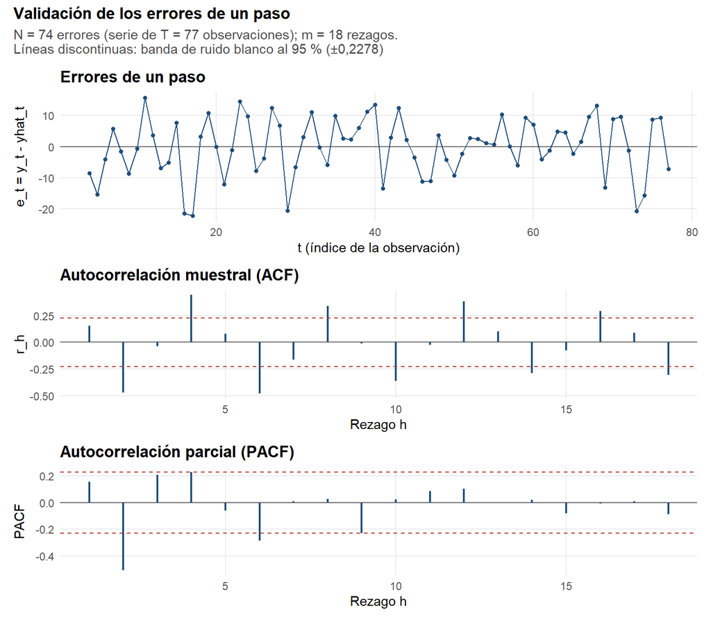

```r
cot <- .cotas("ej04", sum(!is.na(fit$errores)))
ve <- validar_errores(fit$errores, fit$n_param, T_est, cot$dL, cot$dU)
ve$grafico
```

Son $N = 74$ errores de un paso ($2k - 1 = 3$ trimestres quedan sin pronóstico), con $m = 18$ rezagos y banda de ±0,2278, calculada sobre $N$.

```r
pp(ve$t_media, paste0("El error medio fue ", n4(mean(ve$e)), " y el valor p fue ", pv(ve$t_media$valor_p),
                      ". Por lo tanto, no se rechaza la hipótesis de media cero y no hay evidencia de sesgo dentro de la muestra."))
```

**Prueba t de media cero de los errores** (n = 74)

1. **Hipótesis.** $H_0:\ \mu_e = 0$; $H_1:\ \mu_e \neq 0$.
2. **Estadístico y distribución bajo $H_0$.** $t = \dfrac{\bar{e}}{s_e/\sqrt{N}}\ \overset{H_0}{\sim}\ t_{N-1}$; grados de libertad: $73$.
3. **Región de rechazo al 5 %.** $|t| > t_{0{,}975;\,73} = 1,9930$.
4. **Valor observado.** estadístico observado = -0,0509; valor p = 0,960.
5. **Decisión.** No se rechaza $H_0$ (nivel de significancia del 5 %).
6. **Lectura.** El error medio fue -0,0551 y el valor p fue 0,960. Por lo tanto, no se rechaza la hipótesis de media cero y no hay evidencia de sesgo dentro de la muestra.

```r
pp(ve$ljung_box, paste0("El valor p fue ", pv(ve$ljung_box$valor_p), ", por lo que se rechaza que los errores sean ",
                        "incorrelacionados. Al revisar la ACF aparecen patrones alternos en los rezagos pares, como r_2 = ",
                        n4(ve$correlograma$acf[2]), ", r_4 = ", n4(ve$correlograma$acf[4]), " y r_6 = ",
                        n4(ve$correlograma$acf[6]), ". Este comportamiento es compatible con una posible estacionalidad ",
                        "trimestral de período ", frequency(x), ". No se comprobó por separado, por lo que se debe tomar como una ",
                        "posible explicación y no como una conclusión definitiva."))
```

**Prueba de Ljung–Box sobre los errores** (n = 74)

1. **Hipótesis.** $H_0:\ \rho_1 = \rho_2 = \cdots = \rho_m = 0$; $H_1:\ \exists\, h \le m$ con $\rho_h \neq 0$.
2. **Estadístico y distribución bajo $H_0$.** $Q_m = T(T+2)\sum_{h=1}^{m} \dfrac{r_h^2}{T-h}\ \overset{H_0}{\sim}\ \chi^2_{m-p}$; $m = 18$, $p = 1$, luego los grados de libertad son $m - p = 17$.
3. **Región de rechazo al 5 %.** $Q_m > \chi^2_{0{,}95;\,17} = 27,5871$.
4. **Valor observado.** estadístico observado = 118,8368; valor p < 0,001.
5. **Decisión.** Se rechaza $H_0$ (nivel de significancia del 5 %).
6. **Lectura.** El valor p fue < 0,001, por lo que se rechaza que los errores sean incorrelacionados. Al revisar la ACF aparecen patrones alternos en los rezagos pares, como r_2 = -0,4719, r_4 = 0,4414 y r_6 = -0,4782. Este comportamiento es compatible con una posible estacionalidad trimestral de período 4. No se comprobó por separado, por lo que se debe tomar como una posible explicación y no como una conclusión definitiva.

```r
pp(ve$jarque_bera, paste0("El valor p fue ", pv(ve$jarque_bera$valor_p), ", por lo que no se rechaza la normalidad de los ",
                          "errores. No hay evidencia suficiente para decir que los errores se alejen de una distribución normal."))
```

**Prueba de Jarque–Bera** (n = 74)

1. **Hipótesis.** $H_0:\ A = 0\ \text{y}\ K = 3$ (errores normales); $H_1:\ A \neq 0\ \text{o}\ K \neq 3$.
2. **Estadístico y distribución bajo $H_0$.** $JB = \dfrac{N}{6}\left[A^2 + \dfrac{(K-3)^2}{4}\right]\ \overset{H_0}{\sim}\ \chi^2_2$, con $A = m_3/m_2^{3/2}$ la asimetría y $K = m_4/m_2^2$ la curtosis muestrales; grados de libertad: $2$.
3. **Región de rechazo al 5 %.** $JB > \chi^2_{0{,}95;\,2} = 5,9915$.
4. **Valor observado.** estadístico observado = 3,4937; valor p = 0,174.
5. **Decisión.** No se rechaza $H_0$ (nivel de significancia del 5 %).
6. **Lectura.** El valor p fue 0,174, por lo que no se rechaza la normalidad de los errores. No hay evidencia suficiente para decir que los errores se alejen de una distribución normal.

```r
pp(ve$durbin_watson, paste0("El estadístico fue ", n4(ve$durbin_watson$estadistico), " y quedó ligeramente por encima de d_U = ",
                            n2(cot$dU), ". Por lo tanto, no se rechaza la ausencia de autocorrelación positiva de orden uno. Esto ",
                            "no contradice el resultado de Ljung–Box, porque Durbin–Watson solo analiza la autocorrelación de ",
                            "primer orden, mientras que Ljung–Box está detectando la estructura que aparece en otros rezagos, ",
                            "especialmente en los pares."))
```

**Prueba de Durbin–Watson** (n = 74)

1. **Hipótesis.** $H_0:\ \rho = 0$ (sin autocorrelación de orden 1); $H_1:\ \rho > 0$.
2. **Estadístico y distribución bajo $H_0$.** $d = \dfrac{\sum_{t=2}^{N}(e_t - e_{t-1})^2}{\sum_{t=1}^{N} e_t^2} \approx 2(1 - r_1)$; sin distribución exacta bajo $H_0$, se decide con las cotas $d_L$ y $d_U$.
3. **Región de rechazo al 5 %.** Se rechaza $H_0$ si $d < d_L = 1,6000$; no se rechaza si $d > d_U = 1,6500$; inconclusa si $d_L \le d \le d_U$.
4. **Valor observado.** estadístico observado = 1,6720; sin valor p exacto (se decide con las cotas tabuladas).
5. **Decisión.** No se rechaza $H_0$ (nivel de significancia del 5 %).
6. **Lectura.** El estadístico fue 1,6720 y quedó ligeramente por encima de d_U = 1,65. Por lo tanto, no se rechaza la ausencia de autocorrelación positiva de orden uno. Esto no contradice el resultado de Ljung–Box, porque Durbin–Watson solo analiza la autocorrelación de primer orden, mientras que Ljung–Box está detectando la estructura que aparece en otros rezagos, especialmente en los pares.

## 6.7 Gráfico final

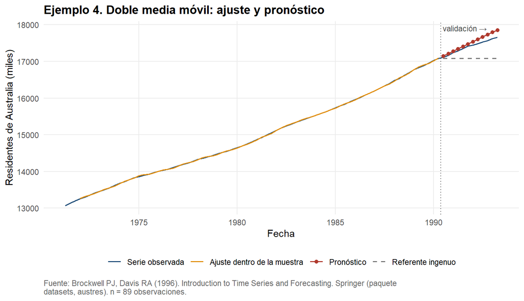

```r
.grafico_pronostico(d, fit$yhat, pron, ref, "Ejemplo 4. Doble media móvil: ajuste y pronóstico")
```

## 6.8 Conclusión

La doble media móvil con $k =$ 2 tuvo un comportamiento bastante mejor que el pronóstico ingenuo. En la validación, el MASE fue 1,8632 frente a 6,0912 y el MSE se redujo en 90,49 %.

Las pruebas de los errores dieron resultados mixtos. No se encontró sesgo (valor p 0,960) ni problemas de normalidad (Jarque–Bera, valor p 0,174) y tampoco se detectó autocorrelación positiva de primer orden con Durbin–Watson (1,6720 frente a $d_U =$ 1,65). Sin embargo, Ljung–Box sí rechazó la independencia de los errores (valor p < 0,001), con una estructura de período 4 en los rezagos pares que es compatible con una posible estacionalidad trimestral, no comprobada por separado.

Además, en 12 de los 12 trimestres de validación el método sobrestimó la población. Por eso, aunque el método mejora bastante al ingenuo, todavía presenta una limitación relacionada con la forma en que extrapola la tendencia.

## 6.9 Recomendación

El método puede ser útil para hacer pronósticos de la población de Australia a corto plazo, aproximadamente entre uno y cuatro trimestres. En ese rango los errores todavía son relativamente pequeños: hasta 53,20 miles de residentes en el horizonte 4, un 0,31 % del valor observado.

El principal límite es que la pendiente se estima utilizando únicamente los últimos dos trimestres (con $k = 2$, $\hat\beta_1 = (Y_T - Y_{T-2})/2 =$ 64,30 miles por trimestre). En la validación el error aumenta de 45,40 en el primer horizonte a 198,10 en el horizonte 12. Esto muestra que el error va creciendo a medida que se extiende el pronóstico.

Por eso, para horizontes más largos sería conveniente actualizar el modelo con los nuevos datos disponibles.

# 7 Ejemplo 5. Tendencia lineal sobre `LakeHuron`

## 7.1 Descripción de la serie

```r
x <- LakeHuron
d <- leer_serie(x,
                fuente = "Brockwell PJ, Davis RA (1991). Time Series: Theory and Methods, 2nd ed. Springer, page 555 (paquete datasets, LakeHuron)",
                unidad = "Nivel del lago Hurón (pies)")
descripcion(x, "LakeHuron", d)
```

| Campo | Valor |
| --- | --- |
| Nombre en R | LakeHuron |
| Fuente (help) | Brockwell PJ, Davis RA (1991). Time Series: Theory and Methods, 2nd ed. Springer, page 555 (paquete datasets, LakeHuron) |
| Unidad | Nivel del lago Hurón (pies) |
| Frecuencia | 1 |
| Inicio (año, período) | 1875, 1 |
| Fin (año, período) | 1972, 1 |
| Rango de fechas | 1875-01-01 a 1972-01-01 |
| Observaciones | 98 |

La serie es el nivel anual del lago Hurón, en pies.

## 7.2 Patrón de la serie

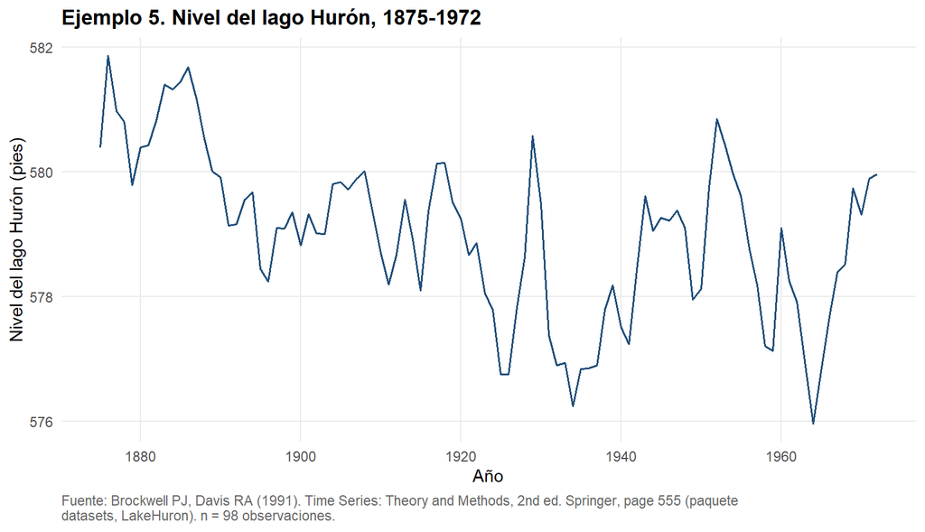

```r
graficar_serie(d, "Ejemplo 5. Nivel del lago Hurón, 1875-1972")
```

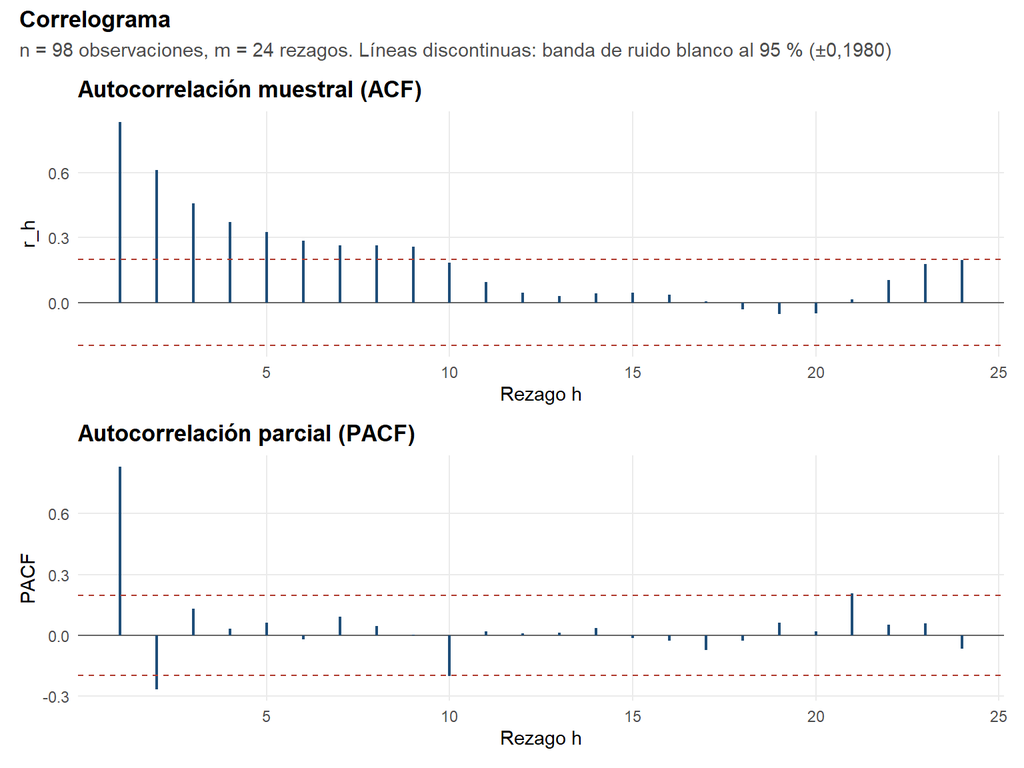

```r
cg <- correlograma(d)
cg$grafico
```

```r
n_total <- nrow(d)
r_1 <- .contraste_rh(cg$acf, n_total, 1)
pp(r_1, paste0("La autocorrelación en el primer rezago fue ", n4(cg$acf[1]), ", muy por encima de la banda de ±", n4(cg$banda),
               ". Esto muestra una relación bastante fuerte entre el nivel de un año y el del año anterior, algo compatible con ",
               "una serie que presenta tendencia o una deriva del nivel."))
```

**Contraste individual de la autocorrelación en el rezago h = 1** (n = 98)

1. **Hipótesis.** $H_0:\ \rho_{1} = 0$; $H_1:\ \rho_{1} \neq 0$.
2. **Estadístico y distribución bajo $H_0$.** $T^* = \dfrac{r_h}{\sqrt{1/n}} = \sqrt{n}\, r_h\ \overset{H_0}{\approx}\ N(0,1)$.
3. **Región de rechazo al 5 %.** $|T^*| > z_{0{,}975} = 1,9600$, es decir $|r_{1}| > 0,1980$.
4. **Valor observado.** estadístico observado = 8,2355; valor p < 0,001.
5. **Decisión.** Se rechaza $H_0$ (nivel de significancia del 5 %).
6. **Lectura.** La autocorrelación en el primer rezago fue 0,8319, muy por encima de la banda de ±0,1980. Esto muestra una relación bastante fuerte entre el nivel de un año y el del año anterior, algo compatible con una serie que presenta tendencia o una deriva del nivel.

```r
h_10 <- which(abs(cg$acf) < cg$banda)[1]
r_10 <- .contraste_rh(cg$acf, n_total, h_10)
pp(r_10, paste0("La autocorrelación entra en la banda por primera vez en el rezago ", h_10, ", con un valor de ", n4(cg$acf[h_10]),
                ". Esto significa que la dependencia tarda bastante en desaparecer y es compatible con una tendencia descendente ",
                "acompañada de fluctuaciones que tienen memoria."))
```

**Contraste individual de la autocorrelación en el rezago h = 10** (n = 98)

1. **Hipótesis.** $H_0:\ \rho_{10} = 0$; $H_1:\ \rho_{10} \neq 0$.
2. **Estadístico y distribución bajo $H_0$.** $T^* = \dfrac{r_h}{\sqrt{1/n}} = \sqrt{n}\, r_h\ \overset{H_0}{\approx}\ N(0,1)$.
3. **Región de rechazo al 5 %.** $|T^*| > z_{0{,}975} = 1,9600$, es decir $|r_{10}| > 0,1980$.
4. **Valor observado.** estadístico observado = 1,8090; valor p = 0,070.
5. **Decisión.** No se rechaza $H_0$ (nivel de significancia del 5 %).
6. **Lectura.** La autocorrelación entra en la banda por primera vez en el rezago 10, con un valor de 0,1827. Esto significa que la dependencia tarda bastante en desaparecer y es compatible con una tendencia descendente acompañada de fluctuaciones que tienen memoria.

```r
lb0 <- ljung_box(cg$acf, n_total, cg$m, 0)
pp(lb0, paste0("El valor p fue ", pv(lb0$valor_p), ", por lo que se rechaza que la serie sea ruido blanco. La serie tiene ",
               "una estructura clara y no puede considerarse simplemente aleatoria."))
```

**Prueba de Ljung–Box** (n = 98)

1. **Hipótesis.** $H_0:\ \rho_1 = \rho_2 = \cdots = \rho_m = 0$; $H_1:\ \exists\, h \le m$ con $\rho_h \neq 0$.
2. **Estadístico y distribución bajo $H_0$.** $Q_m = T(T+2)\sum_{h=1}^{m} \dfrac{r_h^2}{T-h}\ \overset{H_0}{\sim}\ \chi^2_{m-p}$; $m = 24$, $p = 0$, luego los grados de libertad son $m - p = 24$.
3. **Región de rechazo al 5 %.** $Q_m > \chi^2_{0{,}95;\,24} = 36,4150$.
4. **Valor observado.** estadístico observado = 203,2368; valor p < 0,001.
5. **Decisión.** Se rechaza $H_0$ (nivel de significancia del 5 %).
6. **Lectura.** El valor p fue < 0,001, por lo que se rechaza que la serie sea ruido blanco. La serie tiene una estructura clara y no puede considerarse simplemente aleatoria.

**Lectura del patrón.** El nivel del lago Hurón presenta una tendencia descendente, aunque los datos tienen bastante variación alrededor de esa tendencia. La regresión lineal explica solo el 27,25 % de la variación y la autocorrelación se mantiene durante varios rezagos.

Esto hace que la serie sea útil para mostrar qué ocurre cuando se ajusta una tendencia lineal pero los residuos todavía tienen dependencia. Por esa razón también se utilizan errores estándar robustos y la prueba de Durbin–Watson.

## 7.3 Partición

```r
h <- min(12, floor(0.2 * n_total)); T_est <- n_total - h
est <- d[seq_len(T_est), ]; val <- d[T_est + seq_len(h), ]
```

Con $T = 98$ y $h = 12$, el tramo de estimación va de 1875 a 1960 ($T_{est} = 86$) y el de validación de 1961 a 1972.

## 7.4 Ajuste y medidas

La tendencia lineal no tiene constantes por elegir: sus coeficientes son la solución de las ecuaciones normales, así que no se usa `optimizar()`. Los `yhat` son los valores ajustados de la regresión sobre todo el tramo de estimación; **no** son pronósticos con información hasta $t-1$, y por eso el MSE dentro de muestra es optimista y no debe compararse con el de los métodos de suavizamiento.

```r
fit <- ajustar_tendencia(est$y, "lineal")
p <- fit$parametros
pron <- fit$pronosticar(h)
ref <- rep(est$y[T_est], h)                       # ingenuo: el último valor observado
m_in <- .medir(est$y, fit$yhat, est$y)            # ajuste dentro del tramo de estimación
m_val <- .medir(val$y, pron, est$y)               # h pronósticos sobre el tramo de validación
m_ref <- .medir(val$y, ref, est$y)                # el ingenuo, mismo tramo y mismo h
tab(.tabla_medidas(m_in, m_val, m_ref, "Ingenuo"))
```

| caso | N | MSE | MAD | MAPE | MASE |
| --- | --- | --- | --- | --- | --- |
| Método, un paso (estimación) | 86 | 1,1594 | 0,8741 | 0,1510 | 1,5225 |
| Método, h pronósticos (validación) | 12 | 2,0681 | 1,1865 | 0,2050 | 2,0667 |
| Ingenuo, h pronósticos (validación) | 12 | 2,2384 | 1,2425 | 0,2151 | 2,1642 |

```r
# El suavizamiento exponencial simple sobre los mismos datos, como segundo punto de comparación
ses_lh <- ajustar_ses(est$y, optimizar(est$y, "ses")$optimo$alpha)
m_ses <- .medir(val$y, ses_lh$pronosticar(h), est$y)
e_m <- val$y - pron; e_r <- val$y - ref           # errores de validación del método y del ingenuo
```

La tendencia lineal mejora ligeramente al pronóstico ingenuo. El MASE pasa de 2,1642 a 2,0667 y el MSE de 2,2384 a 2,0681.

Sin embargo, la diferencia es pequeña. Además, el suavizamiento exponencial simple obtiene un MASE de 2,1413, por lo que los tres métodos tienen resultados bastante cercanos (a 4,72 % entre sí). Con estos datos no hay una diferencia suficientemente grande como para afirmar que uno sea claramente superior a los demás.

## 7.5 Validación de los errores de un paso

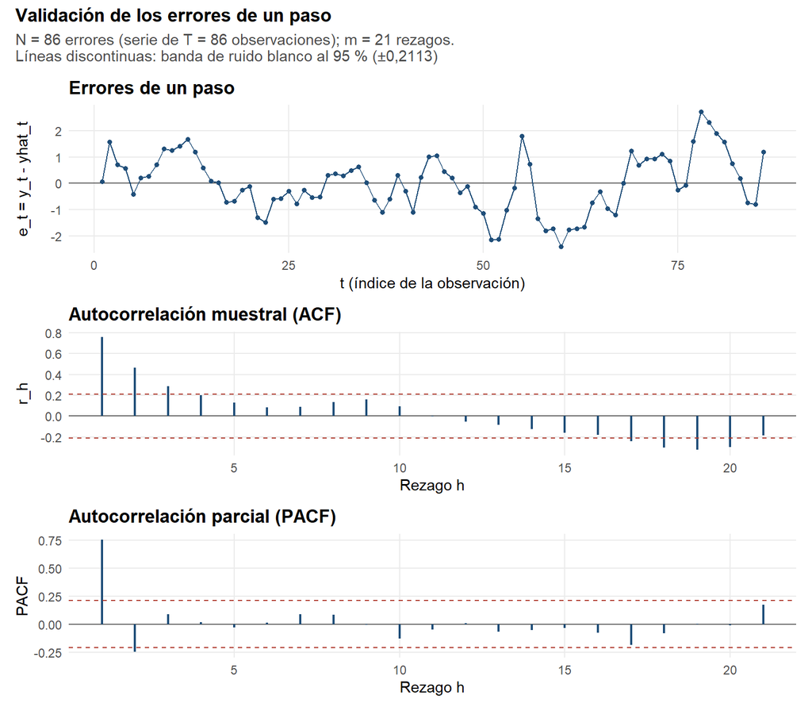

```r
cot <- .cotas("ej05", sum(!is.na(fit$errores)))
ve <- validar_errores(fit$errores, fit$n_param, T_est, cot$dL, cot$dU)
ve$grafico
```

Son $N = 86$ errores, uno por cada observación de estimación porque la regresión ajusta todas. Al ser los `yhat` valores ajustados, **los errores coinciden con los residuos de la regresión**, de modo que las pruebas siguientes son a la vez la revisión de los supuestos de la regresión sobre el error: media cero, ausencia de autocorrelación y normalidad. Con $m = 21$ rezagos la banda es de ±0,2113, calculada sobre $N$.

```r
pp(ve$t_media, paste0("El promedio de los residuos es prácticamente cero (", n4(mean(ve$e)), ") y el valor p es ",
                      pv(ve$t_media$valor_p), ". En este caso, la prueba no aporta mucha información porque en una regresión por ",
                      "mínimos cuadrados con intercepto los residuos suman cero por construcción. Por eso, el resultado importante ",
                      "sobre los residuos se encuentra en las pruebas de autocorrelación."))
```

**Prueba t de media cero de los errores** (n = 86)

1. **Hipótesis.** $H_0:\ \mu_e = 0$; $H_1:\ \mu_e \neq 0$.
2. **Estadístico y distribución bajo $H_0$.** $t = \dfrac{\bar{e}}{s_e/\sqrt{N}}\ \overset{H_0}{\sim}\ t_{N-1}$; grados de libertad: $85$.
3. **Región de rechazo al 5 %.** $|t| > t_{0{,}975;\,85} = 1,9883$.
4. **Valor observado.** estadístico observado = -0,0000; valor p = 1,000.
5. **Decisión.** No se rechaza $H_0$ (nivel de significancia del 5 %).
6. **Lectura.** El promedio de los residuos es prácticamente cero (-0,0000) y el valor p es 1,000. En este caso, la prueba no aporta mucha información porque en una regresión por mínimos cuadrados con intercepto los residuos suman cero por construcción. Por eso, el resultado importante sobre los residuos se encuentra en las pruebas de autocorrelación.

```r
pp(ve$ljung_box, paste0("El valor p fue ", pv(ve$ljung_box$valor_p), ", por lo que se rechaza que los residuos sean ",
                        "incorrelacionados. Además, ", sum(abs(ve$correlograma$acf) > ve$correlograma$banda), " de los ",
                        ve$correlograma$m, " rezagos quedan por fuera de la banda y r_1 = ", n4(ve$correlograma$acf[1]),
                        ". Esto muestra que la recta no está capturando toda la dinámica de la serie. Aunque la tendencia lineal ",
                        "describe una parte del comportamiento, todavía queda bastante estructura en los residuos."))
```

**Prueba de Ljung–Box sobre los errores** (n = 86)

1. **Hipótesis.** $H_0:\ \rho_1 = \rho_2 = \cdots = \rho_m = 0$; $H_1:\ \exists\, h \le m$ con $\rho_h \neq 0$.
2. **Estadístico y distribución bajo $H_0$.** $Q_m = T(T+2)\sum_{h=1}^{m} \dfrac{r_h^2}{T-h}\ \overset{H_0}{\sim}\ \chi^2_{m-p}$; $m = 21$, $p = 2$, luego los grados de libertad son $m - p = 19$.
3. **Región de rechazo al 5 %.** $Q_m > \chi^2_{0{,}95;\,19} = 30,1435$.
4. **Valor observado.** estadístico observado = 141,0602; valor p < 0,001.
5. **Decisión.** Se rechaza $H_0$ (nivel de significancia del 5 %).
6. **Lectura.** El valor p fue < 0,001, por lo que se rechaza que los residuos sean incorrelacionados. Además, 7 de los 21 rezagos quedan por fuera de la banda y r_1 = 0,7565. Esto muestra que la recta no está capturando toda la dinámica de la serie. Aunque la tendencia lineal describe una parte del comportamiento, todavía queda bastante estructura en los residuos.

```r
pp(ve$jarque_bera, paste0("El valor p fue ", pv(ve$jarque_bera$valor_p), ", por lo que no se rechaza la normalidad de los ",
                          "residuos. Sin embargo, que los residuos sean aproximadamente normales no soluciona el problema de ",
                          "autocorrelación encontrado anteriormente."))
```

**Prueba de Jarque–Bera** (n = 86)

1. **Hipótesis.** $H_0:\ A = 0\ \text{y}\ K = 3$ (errores normales); $H_1:\ A \neq 0\ \text{o}\ K \neq 3$.
2. **Estadístico y distribución bajo $H_0$.** $JB = \dfrac{N}{6}\left[A^2 + \dfrac{(K-3)^2}{4}\right]\ \overset{H_0}{\sim}\ \chi^2_2$, con $A = m_3/m_2^{3/2}$ la asimetría y $K = m_4/m_2^2$ la curtosis muestrales; grados de libertad: $2$.
3. **Región de rechazo al 5 %.** $JB > \chi^2_{0{,}95;\,2} = 5,9915$.
4. **Valor observado.** estadístico observado = 0,6155; valor p = 0,735.
5. **Decisión.** No se rechaza $H_0$ (nivel de significancia del 5 %).
6. **Lectura.** El valor p fue 0,735, por lo que no se rechaza la normalidad de los residuos. Sin embargo, que los residuos sean aproximadamente normales no soluciona el problema de autocorrelación encontrado anteriormente.

```r
pp(ve$durbin_watson, paste0("El estadístico fue ", n4(ve$durbin_watson$estadistico), ", muy por debajo de d_L = ", n2(cot$dL),
                            ". Por lo tanto, se rechaza la ausencia de autocorrelación positiva de orden uno. El resultado coincide ",
                            "con r_1 = ", n4(ve$correlograma$acf[1]), " y confirma que existe una fuerte dependencia entre los ",
                            "residuos consecutivos."))
```

**Prueba de Durbin–Watson** (n = 86)

1. **Hipótesis.** $H_0:\ \rho = 0$ (sin autocorrelación de orden 1); $H_1:\ \rho > 0$.
2. **Estadístico y distribución bajo $H_0$.** $d = \dfrac{\sum_{t=2}^{N}(e_t - e_{t-1})^2}{\sum_{t=1}^{N} e_t^2} \approx 2(1 - r_1)$; sin distribución exacta bajo $H_0$, se decide con las cotas $d_L$ y $d_U$.
3. **Región de rechazo al 5 %.** Se rechaza $H_0$ si $d < d_L = 1,6300$; no se rechaza si $d > d_U = 1,6700$; inconclusa si $d_L \le d \le d_U$.
4. **Valor observado.** estadístico observado = 0,4725; sin valor p exacto (se decide con las cotas tabuladas).
5. **Decisión.** Se rechaza $H_0$ (nivel de significancia del 5 %).
6. **Lectura.** El estadístico fue 0,4725, muy por debajo de d_L = 1,63. Por lo tanto, se rechaza la ausencia de autocorrelación positiva de orden uno. El resultado coincide con r_1 = 0,7565 y confirma que existe una fuerte dependencia entre los residuos consecutivos.

## 7.6 Coeficientes y supuestos de la regresión

```r
tab(tabla_coef(fit))
```

|  | Coeficiente | Estimación | EE ordinario | EE robusto | t robusto | p robusto | p ordinario |
| --- | --- | --- | --- | --- | --- | --- | --- |
|  | beta0 | 580,3436 | 0,2370 | 0,3307 | 1754,973 | < 0,001 | < 0,001 |
| t | beta1 | -0,0285 | 0,0047 | 0,0081 | -3,514 | < 0,001 | < 0,001 |

$R^2 =$ 0,3008, $\hat\sigma^2 =$ 1,1870 (suma de cuadrados residual entre $T - p =$ 84), estadístico de Durbin–Watson de los residuos 0,4725 y 3 rezagos en el error estándar robusto ($L = \lfloor 4 (T/100)^{2/9}\rfloor$).

**Por qué se decide con el error estándar robusto.** Como los residuos presentan autocorrelación, los errores estándar normales pueden subestimar la incertidumbre de los coeficientes. Por eso se utiliza el error estándar robusto.

En este caso, el error estándar de la pendiente aumenta 1,71 veces al utilizar el método robusto. Esto muestra que los valores p obtenidos con el error estándar común podían dar una impresión de mayor precisión de la que realmente existe, y por eso no son interpretables: la decisión sobre cada coeficiente se toma con el robusto.

```r
t_b0 <- .t_coeficiente(r"(\beta_0)", p$tabla$estimacion[1], p$tabla$ee_robusto[1], p$gl, T_est)
pp(t_b0, paste0("El intercepto β_0 = ", n4(p$tabla$estimacion[1]), " es estadísticamente significativo (t = ",
                n4(t_b0$estadistico), "), pero su interpretación no es especialmente importante, ya que corresponde al nivel de ",
                "la recta cuando t = 0, un período anterior al inicio de los datos. Lo más relevante en este ejemplo es la ",
                "pendiente y el comportamiento de los residuos."))
```

**Prueba t del coeficiente $\beta_0$ con error estándar robusto** (n = 86)

1. **Hipótesis.** $H_0:\ \beta_0 = 0$; $H_1:\ \beta_0 \neq 0$.
2. **Estadístico y distribución bajo $H_0$.** $t = \dfrac{\hat{\beta_0}}{\widehat{EE}_{HAC}(\hat{\beta_0})}\ \overset{H_0}{\approx}\ t_{T-p}$; grados de libertad: $84$.
3. **Región de rechazo al 5 %.** $|t| > t_{0{,}975;\,84} = 1,9886$.
4. **Valor observado.** estadístico observado = 1754,9727; valor p < 0,001.
5. **Decisión.** Se rechaza $H_0$ (nivel de significancia del 5 %).
6. **Lectura.** El intercepto β_0 = 580,3436 es estadísticamente significativo (t = 1754,9727), pero su interpretación no es especialmente importante, ya que corresponde al nivel de la recta cuando t = 0, un período anterior al inicio de los datos. Lo más relevante en este ejemplo es la pendiente y el comportamiento de los residuos.

```r
t_b1 <- .t_coeficiente(r"(\beta_1)", p$tabla$estimacion[2], p$tabla$ee_robusto[2], p$gl, T_est)
pp(t_b1, paste0("La pendiente es β_1 = ", n4(p$tabla$estimacion[2]), " pies por año y el valor p con el error estándar robusto es ",
                pv(t_b1$valor_p), " (t = ", n4(t_b1$estadistico), "). Por lo tanto, se rechaza que la pendiente sea cero y existe ",
                "evidencia de una tendencia descendente. El uso del error robusto hace que la evidencia sea menor que con el error ",
                "estándar normal (t = ", n4(p$tabla$estimacion[2] / p$tabla$ee_ordinario[2]), "), pero la conclusión sobre la ",
                "pendiente negativa se mantiene."))
```

**Prueba t del coeficiente $\beta_1$ con error estándar robusto** (n = 86)

1. **Hipótesis.** $H_0:\ \beta_1 = 0$; $H_1:\ \beta_1 \neq 0$.
2. **Estadístico y distribución bajo $H_0$.** $t = \dfrac{\hat{\beta_1}}{\widehat{EE}_{HAC}(\hat{\beta_1})}\ \overset{H_0}{\approx}\ t_{T-p}$; grados de libertad: $84$.
3. **Región de rechazo al 5 %.** $|t| > t_{0{,}975;\,84} = 1,9886$.
4. **Valor observado.** estadístico observado = -3,5140; valor p < 0,001.
5. **Decisión.** Se rechaza $H_0$ (nivel de significancia del 5 %).
6. **Lectura.** La pendiente es β_1 = -0,0285 pies por año y el valor p con el error estándar robusto es < 0,001 (t = -3,5140). Por lo tanto, se rechaza que la pendiente sea cero y existe evidencia de una tendencia descendente. El uso del error robusto hace que la evidencia sea menor que con el error estándar normal (t = -6,0121), pero la conclusión sobre la pendiente negativa se mantiene.

**Varianza constante.** No hay una prueba formal en el protocolo; se revisa con el gráfico de residuos contra valores ajustados.

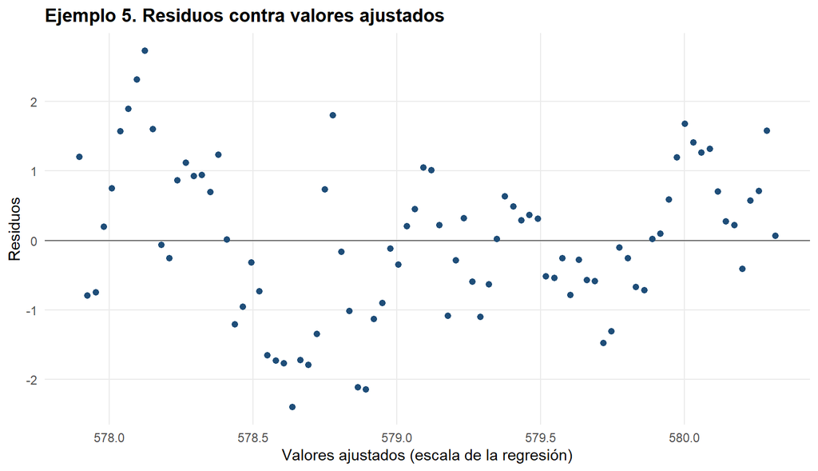

```r
.grafico_residuos_ajustados(est$y - p$residuos, p$residuos, "Ejemplo 5. Residuos contra valores ajustados")
```

Los residuos no muestran un patrón claro de abanico (van de -2,40 a 2,73 pies), por lo que no hay evidencia visual fuerte de una varianza que cambie con el nivel. Sin embargo, sí aparecen ondas de residuos positivos y negativos, que coinciden con la autocorrelación detectada.

En general, la normalidad y la varianza parecen razonables, pero la independencia no se cumple. Por eso es necesario utilizar errores estándar robustos para la inferencia.

## 7.7 Gráfico final

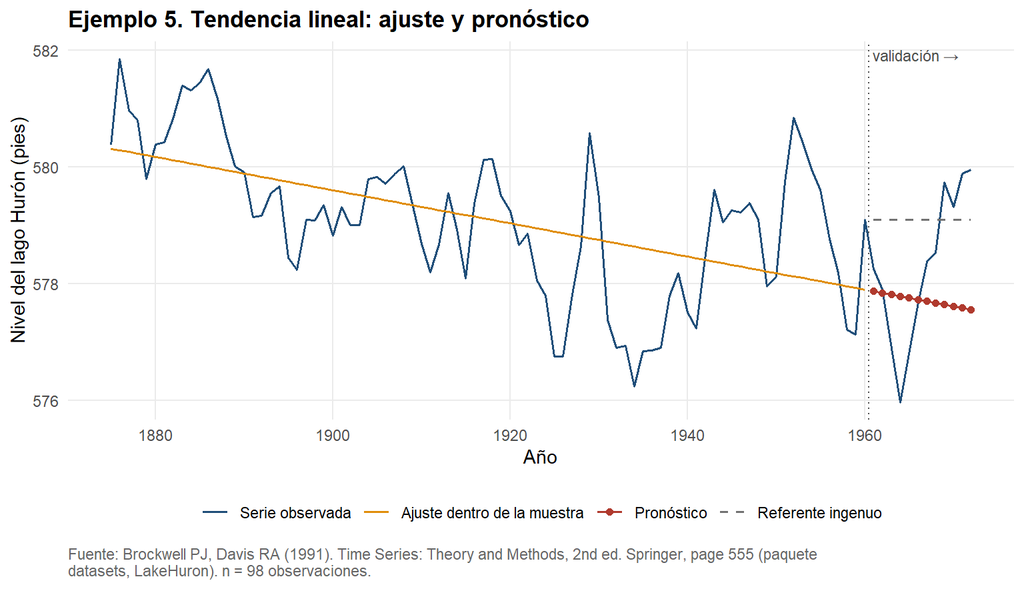

```r
.grafico_pronostico(d, fit$yhat, pron, ref, "Ejemplo 5. Tendencia lineal: ajuste y pronóstico")
```

## 7.8 Conclusión

La tendencia lineal estimada fue $\hat Y_t = 580,34 -0,0285\,t$ y la pendiente resultó significativa utilizando el error estándar robusto ($t =$ -3,5140, valor p < 0,001). En validación, el método obtuvo un MASE de 2,0667 frente a 2,1642 del ingenuo, por lo que sí mejora, aunque por un margen pequeño de 4,51 %.

El principal problema aparece en los residuos. Ljung–Box (valor p < 0,001) y Durbin–Watson (0,4725 frente a $d_L =$ 1,63) muestran una autocorrelación importante, aunque la prueba de Jarque–Bera (valor p 0,735) no encuentra problemas de normalidad.

Por lo tanto, la tendencia lineal logra captar parte del comportamiento general de la serie, pero todavía queda una estructura importante que el modelo no explica.

## 7.9 Recomendación

La tendencia lineal puede servir como una referencia para algunos años hacia adelante, pero no es conveniente extenderla demasiado. En la validación fue mejor que el ingenuo durante los primeros 7 años, pero después comenzó a tener errores mayores.

El problema es que la recta continúa disminuyendo (de 577,87 a 577,56 pies) mientras el lago posteriormente cambia de comportamiento (de 578,25 a 579,96 pies). En el horizonte 12 el error llega a 2,40 pies, 1,82 veces la desviación estándar de toda la serie (1,32). Por eso, para períodos más largos sería mejor actualizar la tendencia con nuevos datos o utilizar un método que permita que el nivel cambie con el tiempo.

# 8 Ejemplo 6. Tendencia cuadrática sobre `airmiles`

## 8.1 Descripción de la serie

```r
x <- airmiles
d <- leer_serie(x,
                fuente = "F.A.A. Statistical Handbook of Aviation (paquete datasets, airmiles)",
                unidad = "Millas-pasajero de ingreso (revenue passenger miles), aerolíneas comerciales de EE. UU.")
descripcion(x, "airmiles", d)
```

| Campo | Valor |
| --- | --- |
| Nombre en R | airmiles |
| Fuente (help) | F.A.A. Statistical Handbook of Aviation (paquete datasets, airmiles) |
| Unidad | Millas-pasajero de ingreso (revenue passenger miles), aerolíneas comerciales de EE. UU. |
| Frecuencia | 1 |
| Inicio (año, período) | 1937, 1 |
| Fin (año, período) | 1960, 1 |
| Rango de fechas | 1937-01-01 a 1960-01-01 |
| Observaciones | 24 |

Esta serie tiene solamente 24 observaciones anuales, por lo que hay pocos datos para estimar el modelo (20) y únicamente 4 observaciones para validarlo. Esto hace que los resultados de la validación sean útiles como referencia, pero no permitan sacar conclusiones demasiado fuertes.

## 8.2 Patrón de la serie

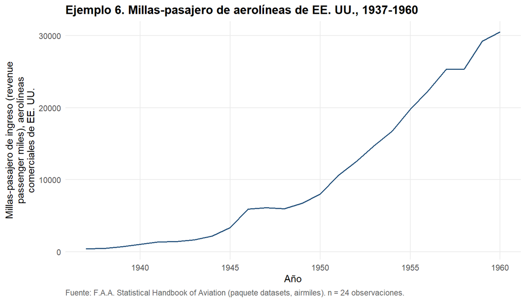

```r
graficar_serie(d, "Ejemplo 6. Millas-pasajero de aerolíneas de EE. UU., 1937-1960")
```

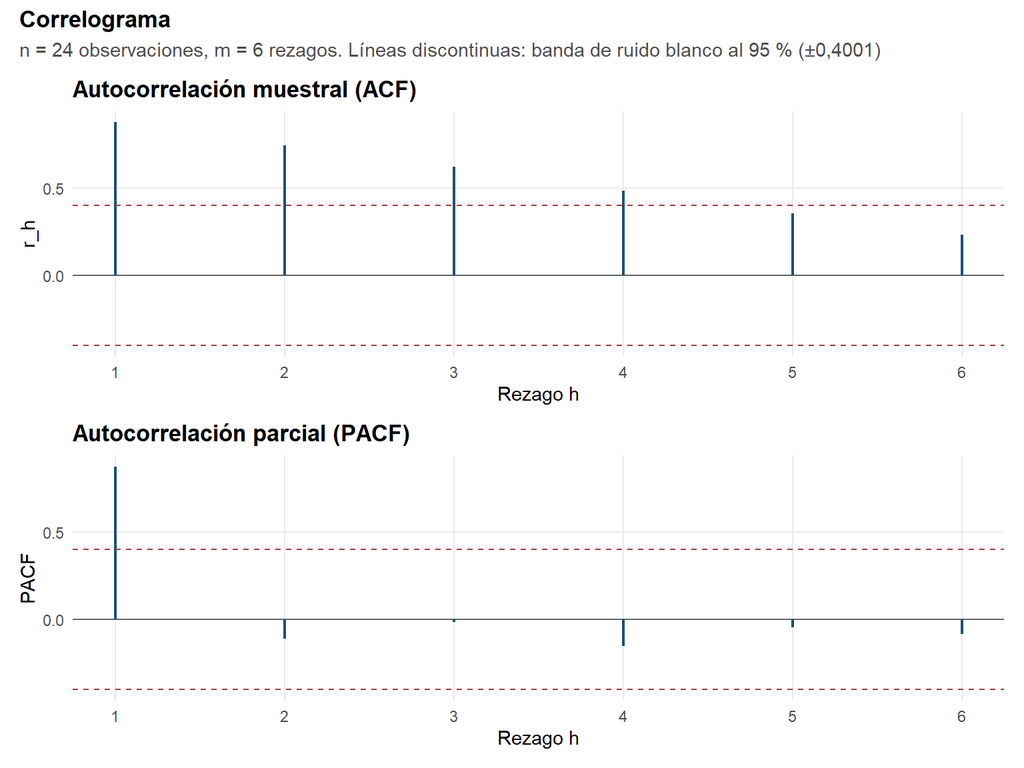

```r
cg <- correlograma(d)
cg$grafico
```

```r
n_total <- nrow(d)
r_1 <- .contraste_rh(cg$acf, n_total, 1)
pp(r_1, paste0("La autocorrelación del primer rezago fue ", n4(cg$acf[1]), " y está bastante por encima de la banda de ±",
               n4(cg$banda), ". Por lo tanto, se rechaza la independencia y se observa una relación muy fuerte entre los valores ",
               "de años consecutivos."))
```

**Contraste individual de la autocorrelación en el rezago h = 1** (n = 24)

1. **Hipótesis.** $H_0:\ \rho_{1} = 0$; $H_1:\ \rho_{1} \neq 0$.
2. **Estadístico y distribución bajo $H_0$.** $T^* = \dfrac{r_h}{\sqrt{1/n}} = \sqrt{n}\, r_h\ \overset{H_0}{\approx}\ N(0,1)$.
3. **Región de rechazo al 5 %.** $|T^*| > z_{0{,}975} = 1,9600$, es decir $|r_{1}| > 0,4001$.
4. **Valor observado.** estadístico observado = 4,2920; valor p < 0,001.
5. **Decisión.** Se rechaza $H_0$ (nivel de significancia del 5 %).
6. **Lectura.** La autocorrelación del primer rezago fue 0,8761 y está bastante por encima de la banda de ±0,4001. Por lo tanto, se rechaza la independencia y se observa una relación muy fuerte entre los valores de años consecutivos.

```r
h_5 <- which(abs(cg$acf) < cg$banda)[1]
r_5 <- .contraste_rh(cg$acf, n_total, h_5)
pp(r_5, paste0("La autocorrelación va disminuyendo de forma gradual, desde ", n2(cg$acf[1]), " hasta ", n2(cg$acf[h_5 - 1]),
               ", y entra en la banda en el rezago ", h_5, " (", n4(cg$acf[h_5]), "). Este descenso lento y sin oscilaciones es ",
               "compatible con una serie que presenta una tendencia fuerte."))
```

**Contraste individual de la autocorrelación en el rezago h = 5** (n = 24)

1. **Hipótesis.** $H_0:\ \rho_{5} = 0$; $H_1:\ \rho_{5} \neq 0$.
2. **Estadístico y distribución bajo $H_0$.** $T^* = \dfrac{r_h}{\sqrt{1/n}} = \sqrt{n}\, r_h\ \overset{H_0}{\approx}\ N(0,1)$.
3. **Región de rechazo al 5 %.** $|T^*| > z_{0{,}975} = 1,9600$, es decir $|r_{5}| > 0,4001$.
4. **Valor observado.** estadístico observado = 1,7434; valor p = 0,081.
5. **Decisión.** No se rechaza $H_0$ (nivel de significancia del 5 %).
6. **Lectura.** La autocorrelación va disminuyendo de forma gradual, desde 0,88 hasta 0,48, y entra en la banda en el rezago 5 (0,3559). Este descenso lento y sin oscilaciones es compatible con una serie que presenta una tendencia fuerte.

```r
lb0 <- ljung_box(cg$acf, n_total, cg$m, 0)
pp(lb0, paste0("El valor p fue ", pv(lb0$valor_p), ", por lo que se rechaza que la serie sea ruido blanco. Hay una estructura ",
               "clara en los datos."))
```

**Prueba de Ljung–Box** (n = 24)

1. **Hipótesis.** $H_0:\ \rho_1 = \rho_2 = \cdots = \rho_m = 0$; $H_1:\ \exists\, h \le m$ con $\rho_h \neq 0$.
2. **Estadístico y distribución bajo $H_0$.** $Q_m = T(T+2)\sum_{h=1}^{m} \dfrac{r_h^2}{T-h}\ \overset{H_0}{\sim}\ \chi^2_{m-p}$; $m = 6$, $p = 0$, luego los grados de libertad son $m - p = 6$.
3. **Región de rechazo al 5 %.** $Q_m > \chi^2_{0{,}95;\,6} = 12,5916$.
4. **Valor observado.** estadístico observado = 61,3067; valor p < 0,001.
5. **Decisión.** Se rechaza $H_0$ (nivel de significancia del 5 %).
6. **Lectura.** El valor p fue < 0,001, por lo que se rechaza que la serie sea ruido blanco. Hay una estructura clara en los datos.

**Lectura del patrón.** La serie presenta un crecimiento que se va acelerando. El promedio de la segunda mitad (18502,17) es mucho mayor que el de la primera (2553,50) y el incremento anual medio pasa de 506,27 a 2044,42. Esto indica que una recta no describe bien el comportamiento, mientras que una tendencia cuadrática $\beta_0 + \beta_1 t + \beta_2 t^2$ sí puede representar una curvatura en el crecimiento.

También se revisó la posibilidad de utilizar una tendencia exponencial (crecimiento a tasa constante), pero la tasa de crecimiento no se mantiene constante. Se calcula la pendiente del logaritmo en cada mitad de la serie, que sería igual en ambas si la tasa fuera constante:

```r
z <- log(d$y); ti <- seq_len(n_total)
pend <- function(i) cov(ti[i], z[i]) / var(ti[i])   # pendiente de mínimos cuadrados de ln y sobre t
p_1 <- pend(1:12); p_2 <- pend(13:24)
```

La pendiente del logaritmo disminuye de 0,2615 a 0,1375, por lo que la exponencial no representa tan bien este comportamiento. Por eso se descarta aquí (más abajo se mide cuánto peor pronostica) y se usa en el ejemplo 7 sobre una serie cuya tasa sí es estable.

## 8.3 Partición

```r
h <- min(12, floor(0.2 * n_total)); T_est <- n_total - h
est <- d[seq_len(T_est), ]; val <- d[T_est + seq_len(h), ]
```

Con $T = 24$ y $h = \min\{12, \lfloor 0{,}2 \cdot 24\rfloor\} = 4$, el tramo de estimación va de 1937 a 1956 ($T_{est} = 20$) y el de validación de 1957 a 1960. Con solo 4 datos de validación las conclusiones sobre el pronóstico son indicativas, no concluyentes.

## 8.4 Ajuste y medidas

La tendencia cuadrática no tiene constantes por elegir (sus coeficientes son la solución de las ecuaciones normales), así que no se usa `optimizar()`. Los `yhat` son valores ajustados de una regresión que usa todo el tramo de estimación, no pronósticos con información hasta $t-1$.

```r
fit <- ajustar_tendencia(est$y, "cuadratica")
p <- fit$parametros
pron <- fit$pronosticar(h)
ref <- rep(est$y[T_est], h)                       # ingenuo: el último valor observado
m_in <- .medir(est$y, fit$yhat, est$y)            # ajuste dentro del tramo de estimación
m_val <- .medir(val$y, pron, est$y)               # h pronósticos sobre el tramo de validación
m_ref <- .medir(val$y, ref, est$y)                # el ingenuo, mismo tramo y mismo h
tab(.tabla_medidas(m_in, m_val, m_ref, "Ingenuo"), 3)
```

| caso | N | MSE | MAD | MAPE | MASE |
| --- | --- | --- | --- | --- | --- |
| Método, un paso (estimación) | 20 | 472846,5 | 518,454 | 20,565 | 0,444 |
| Método, h pronósticos (validación) | 4 | 2416497,7 | 1408,887 | 5,092 | 1,205 |
| Ingenuo, h pronósticos (validación) | 4 | 32979149,5 | 5254,500 | 18,457 | 4,496 |

```r
# Las alternativas descartadas, sobre el mismo tramo de validación
m_lin <- .medir(val$y, ajustar_tendencia(est$y, "lineal")$pronosticar(h), est$y)
m_exp <- .medir(val$y, ajustar_tendencia(est$y, "exponencial")$pronosticar(h), est$y)
e_m <- val$y - pron; e_r <- val$y - ref           # errores de validación del método y del ingenuo
```

La tendencia cuadrática mejora bastante al pronóstico ingenuo. El MASE baja de 4,4959 a 1,2055 y el MSE se reduce en 92,67 %.

Además, la comparación con los otros modelos respalda la elección de la parábola: la recta obtuvo un MASE de 6,3852 y la exponencial de 19,8685. En este caso, la forma cuadrática representa mejor la aceleración observada en la serie.

## 8.5 Validación de los errores de un paso

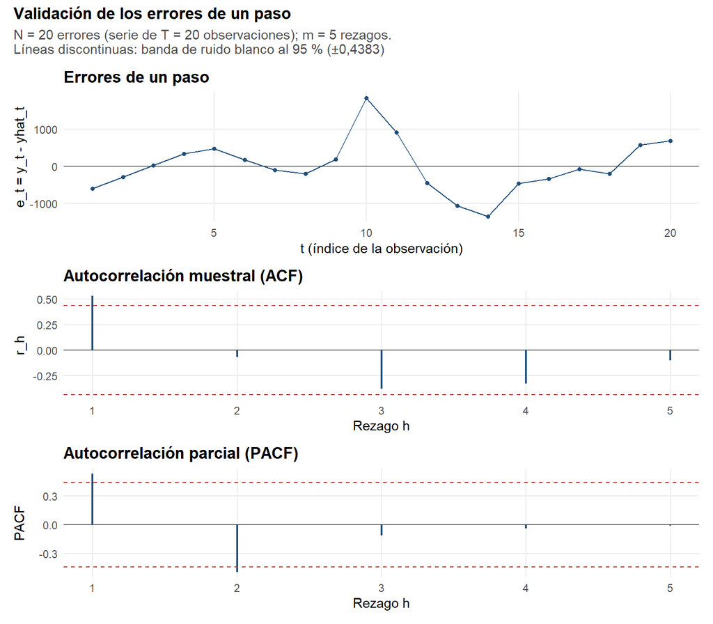

```r
cot <- .cotas("ej06", sum(!is.na(fit$errores)))
ve <- validar_errores(fit$errores, fit$n_param, T_est, cot$dL, cot$dU)
ve$grafico
```

Son $N = 20$ errores, uno por cada observación de estimación. Como los `yhat` son valores ajustados, **los errores coinciden con los residuos de la regresión** y las pruebas siguientes revisan a la vez los supuestos de la regresión. Con solo $N = 20$ el número de rezagos es $m = 5$ y la banda es ancha (±0,4383), de modo que las pruebas tienen poco poder; la prueba de Jarque–Bera está justo en el límite de tamaño en que su distribución asintótica es aceptable ($N = 20$, no menos de veinte).

```r
pp(ve$t_media, paste0("El promedio de los residuos es prácticamente cero (", n4(mean(ve$e)), ") y el valor p es ",
                      pv(ve$t_media$valor_p), ". Como ocurre en una regresión con intercepto, este resultado se debe principalmente ",
                      "a la forma en que se ajusta el modelo y no aporta mucha información sobre la calidad del ajuste."))
```

**Prueba t de media cero de los errores** (n = 20)

1. **Hipótesis.** $H_0:\ \mu_e = 0$; $H_1:\ \mu_e \neq 0$.
2. **Estadístico y distribución bajo $H_0$.** $t = \dfrac{\bar{e}}{s_e/\sqrt{N}}\ \overset{H_0}{\sim}\ t_{N-1}$; grados de libertad: $19$.
3. **Región de rechazo al 5 %.** $|t| > t_{0{,}975;\,19} = 2,0930$.
4. **Valor observado.** estadístico observado = -0,0000; valor p = 1,000.
5. **Decisión.** No se rechaza $H_0$ (nivel de significancia del 5 %).
6. **Lectura.** El promedio de los residuos es prácticamente cero (-0,0000) y el valor p es 1,000. Como ocurre en una regresión con intercepto, este resultado se debe principalmente a la forma en que se ajusta el modelo y no aporta mucha información sobre la calidad del ajuste.

```r
pp(ve$ljung_box, paste0("El valor p fue ", pv(ve$ljung_box$valor_p), ", por lo que se rechaza que los residuos sean ",
                        "incorrelacionados. Esto significa que, aunque la parábola explica muy bien la tendencia general, todavía ",
                        "queda estructura en los residuos (r_1 = ", n4(ve$correlograma$acf[1]), "). Además, la prueba tiene ",
                        "solamente ", ve$ljung_box$gl, " grados de libertad, por lo que no es una prueba con mucha potencia. Aun ",
                        "así, logra rechazar la hipótesis de independencia."))
```

**Prueba de Ljung–Box sobre los errores** (n = 20)

1. **Hipótesis.** $H_0:\ \rho_1 = \rho_2 = \cdots = \rho_m = 0$; $H_1:\ \exists\, h \le m$ con $\rho_h \neq 0$.
2. **Estadístico y distribución bajo $H_0$.** $Q_m = T(T+2)\sum_{h=1}^{m} \dfrac{r_h^2}{T-h}\ \overset{H_0}{\sim}\ \chi^2_{m-p}$; $m = 5$, $p = 3$, luego los grados de libertad son $m - p = 2$.
3. **Región de rechazo al 5 %.** $Q_m > \chi^2_{0{,}95;\,2} = 5,9915$.
4. **Valor observado.** estadístico observado = 13,6329; valor p = 0,001.
5. **Decisión.** Se rechaza $H_0$ (nivel de significancia del 5 %).
6. **Lectura.** El valor p fue 0,001, por lo que se rechaza que los residuos sean incorrelacionados. Esto significa que, aunque la parábola explica muy bien la tendencia general, todavía queda estructura en los residuos (r_1 = 0,5309). Además, la prueba tiene solamente 2 grados de libertad, por lo que no es una prueba con mucha potencia. Aun así, logra rechazar la hipótesis de independencia.

```r
pp(ve$jarque_bera, paste0("El valor p fue ", pv(ve$jarque_bera$valor_p), ", por lo que no se rechaza la normalidad de los ",
                          "residuos. Sin embargo, solo hay ", ve$n, " datos de estimación, así que esta prueba tiene poca capacidad ",
                          "para detectar desviaciones de la normalidad."))
```

**Prueba de Jarque–Bera** (n = 20)

1. **Hipótesis.** $H_0:\ A = 0\ \text{y}\ K = 3$ (errores normales); $H_1:\ A \neq 0\ \text{o}\ K \neq 3$.
2. **Estadístico y distribución bajo $H_0$.** $JB = \dfrac{N}{6}\left[A^2 + \dfrac{(K-3)^2}{4}\right]\ \overset{H_0}{\sim}\ \chi^2_2$, con $A = m_3/m_2^{3/2}$ la asimetría y $K = m_4/m_2^2$ la curtosis muestrales; grados de libertad: $2$.
3. **Región de rechazo al 5 %.** $JB > \chi^2_{0{,}95;\,2} = 5,9915$.
4. **Valor observado.** estadístico observado = 1,5357; valor p = 0,464.
5. **Decisión.** No se rechaza $H_0$ (nivel de significancia del 5 %).
6. **Lectura.** El valor p fue 0,464, por lo que no se rechaza la normalidad de los residuos. Sin embargo, solo hay 20 datos de estimación, así que esta prueba tiene poca capacidad para detectar desviaciones de la normalidad.

```r
pp(ve$durbin_watson, paste0("El estadístico fue ", n4(ve$durbin_watson$estadistico), ", por debajo de d_L = ", n2(cot$dL),
                            ". Por lo tanto, se rechaza la ausencia de autocorrelación positiva de orden uno. Esto coincide con la ",
                            "autocorrelación observada en el primer rezago (r_1 = ", n4(ve$correlograma$acf[1]),
                            ") y muestra que la parábola todavía deja cierta dependencia entre años consecutivos."))
```

**Prueba de Durbin–Watson** (n = 20)

1. **Hipótesis.** $H_0:\ \rho = 0$ (sin autocorrelación de orden 1); $H_1:\ \rho > 0$.
2. **Estadístico y distribución bajo $H_0$.** $d = \dfrac{\sum_{t=2}^{N}(e_t - e_{t-1})^2}{\sum_{t=1}^{N} e_t^2} \approx 2(1 - r_1)$; sin distribución exacta bajo $H_0$, se decide con las cotas $d_L$ y $d_U$.
3. **Región de rechazo al 5 %.** Se rechaza $H_0$ si $d < d_L = 1,1000$; no se rechaza si $d > d_U = 1,5400$; inconclusa si $d_L \le d \le d_U$.
4. **Valor observado.** estadístico observado = 0,8489; sin valor p exacto (se decide con las cotas tabuladas).
5. **Decisión.** Se rechaza $H_0$ (nivel de significancia del 5 %).
6. **Lectura.** El estadístico fue 0,8489, por debajo de d_L = 1,10. Por lo tanto, se rechaza la ausencia de autocorrelación positiva de orden uno. Esto coincide con la autocorrelación observada en el primer rezago (r_1 = 0,5309) y muestra que la parábola todavía deja cierta dependencia entre años consecutivos.

## 8.6 Coeficientes y supuestos de la regresión

```r
tab(tabla_coef(fit))
```

| Coeficiente | Estimación | EE ordinario | EE robusto | t robusto | p robusto | p ordinario |
| --- | --- | --- | --- | --- | --- | --- |
| beta0 | 1420,1246 | 554,8976 | 517,1624 | 2,7460 | 0,014 | 0,020 |
| beta1 | -473,9304 | 121,6976 | 149,3568 | -3,1731 | 0,006 | 0,001 |
| beta2 | 74,3292 | 5,6291 | 6,8758 | 10,8103 | < 0,001 | < 0,001 |

$R^2 =$ 0,9894, $\hat\sigma^2 =$ 556289,98 (entre $T - p =$ 17 grados de libertad), estadístico de Durbin–Watson de los residuos 0,8489 y 2 rezagos en el error estándar robusto.

**Por qué se decide con el error estándar robusto.** Como los residuos presentan autocorrelación (Durbin–Watson por debajo de $d_L$), el error estándar común no es adecuado para hacer la inferencia y sus valores p no son interpretables. Por eso se utiliza el error estándar robusto.

Los errores estándar cambian de manera diferente para cada coeficiente (el de $\beta_0$ pasa de 554,90 a 517,16, el de $\beta_1$ de 121,70 a 149,36 y el de $\beta_2$ de 5,63 a 6,88), pero con solamente 20 datos la precisión sigue siendo limitada. Aun así, el robusto es el que permite tener en cuenta la autocorrelación observada. La decisión sobre cada coeficiente se toma con él:

```r
t_b0 <- .t_coeficiente(r"(\beta_0)", p$tabla$estimacion[1], p$tabla$ee_robusto[1], p$gl, T_est)
pp(t_b0, paste0("El intercepto β_0 = ", n2(p$tabla$estimacion[1]), " resultó significativo (valor p ", pv(t_b0$valor_p),
                "), pero no tiene una interpretación especialmente útil porque corresponde a una extrapolación hacia atrás, ",
                "fuera del período real de la serie."))
```

**Prueba t del coeficiente $\beta_0$ con error estándar robusto** (n = 20)

1. **Hipótesis.** $H_0:\ \beta_0 = 0$; $H_1:\ \beta_0 \neq 0$.
2. **Estadístico y distribución bajo $H_0$.** $t = \dfrac{\hat{\beta_0}}{\widehat{EE}_{HAC}(\hat{\beta_0})}\ \overset{H_0}{\approx}\ t_{T-p}$; grados de libertad: $17$.
3. **Región de rechazo al 5 %.** $|t| > t_{0{,}975;\,17} = 2,1098$.
4. **Valor observado.** estadístico observado = 2,7460; valor p = 0,014.
5. **Decisión.** Se rechaza $H_0$ (nivel de significancia del 5 %).
6. **Lectura.** El intercepto β_0 = 1420,12 resultó significativo (valor p 0,014), pero no tiene una interpretación especialmente útil porque corresponde a una extrapolación hacia atrás, fuera del período real de la serie.

```r
t_b1 <- .t_coeficiente(r"(\beta_1)", p$tabla$estimacion[2], p$tabla$ee_robusto[2], p$gl, T_est)
pp(t_b1, paste0("El coeficiente β_1 = ", n2(p$tabla$estimacion[2]), " resultó significativo (valor p ", pv(t_b1$valor_p),
                "), pero no significa que el tráfico estuviera disminuyendo. En una parábola, este coeficiente debe interpretarse ",
                "junto con β_2. Como β_2 es positivo, la curva alcanza un mínimo alrededor de t = ",
                n2(-p$tabla$estimacion[2] / (2 * p$tabla$estimacion[3])), " y luego comienza a crecer. Por eso, no sería correcto ",
                "interpretar β_1 por separado como una disminución del tráfico."))
```

**Prueba t del coeficiente $\beta_1$ con error estándar robusto** (n = 20)

1. **Hipótesis.** $H_0:\ \beta_1 = 0$; $H_1:\ \beta_1 \neq 0$.
2. **Estadístico y distribución bajo $H_0$.** $t = \dfrac{\hat{\beta_1}}{\widehat{EE}_{HAC}(\hat{\beta_1})}\ \overset{H_0}{\approx}\ t_{T-p}$; grados de libertad: $17$.
3. **Región de rechazo al 5 %.** $|t| > t_{0{,}975;\,17} = 2,1098$.
4. **Valor observado.** estadístico observado = -3,1731; valor p = 0,006.
5. **Decisión.** Se rechaza $H_0$ (nivel de significancia del 5 %).
6. **Lectura.** El coeficiente β_1 = -473,93 resultó significativo (valor p 0,006), pero no significa que el tráfico estuviera disminuyendo. En una parábola, este coeficiente debe interpretarse junto con β_2. Como β_2 es positivo, la curva alcanza un mínimo alrededor de t = 3,19 y luego comienza a crecer. Por eso, no sería correcto interpretar β_1 por separado como una disminución del tráfico.

```r
t_b2 <- .t_coeficiente(r"(\beta_2)", p$tabla$estimacion[3], p$tabla$ee_robusto[3], p$gl, T_est)
pp(t_b2, paste0("El coeficiente β_2 = ", n2(p$tabla$estimacion[3]), " tiene un valor p ", pv(t_b2$valor_p),
                ", por lo que se rechaza que la curvatura sea cero. Este es uno de los resultados más importantes del ejemplo, ",
                "porque muestra que existe evidencia de que el crecimiento no es simplemente lineal, sino que presenta una ",
                "curvatura positiva."))
```

**Prueba t del coeficiente $\beta_2$ con error estándar robusto** (n = 20)

1. **Hipótesis.** $H_0:\ \beta_2 = 0$; $H_1:\ \beta_2 \neq 0$.
2. **Estadístico y distribución bajo $H_0$.** $t = \dfrac{\hat{\beta_2}}{\widehat{EE}_{HAC}(\hat{\beta_2})}\ \overset{H_0}{\approx}\ t_{T-p}$; grados de libertad: $17$.
3. **Región de rechazo al 5 %.** $|t| > t_{0{,}975;\,17} = 2,1098$.
4. **Valor observado.** estadístico observado = 10,8103; valor p < 0,001.
5. **Decisión.** Se rechaza $H_0$ (nivel de significancia del 5 %).
6. **Lectura.** El coeficiente β_2 = 74,33 tiene un valor p < 0,001, por lo que se rechaza que la curvatura sea cero. Este es uno de los resultados más importantes del ejemplo, porque muestra que existe evidencia de que el crecimiento no es simplemente lineal, sino que presenta una curvatura positiva.

**Varianza constante.** Se revisa con el gráfico de residuos contra valores ajustados.

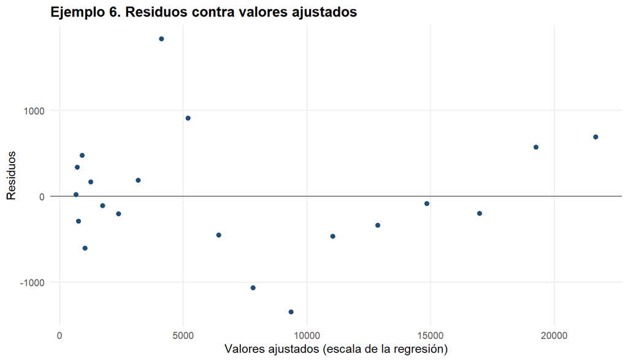

```r
.grafico_residuos_ajustados(est$y - p$residuos, p$residuos, "Ejemplo 6. Residuos contra valores ajustados")
```

Con solamente 20 observaciones no es posible determinar con mucha seguridad si existe un cambio en la varianza o si este patrón se debe simplemente a la forma funcional que todavía falta capturar. En general, la normalidad no se rechaza, pero sí existe autocorrelación y el modelo no explica toda la estructura de la serie.

## 8.7 Gráfico final

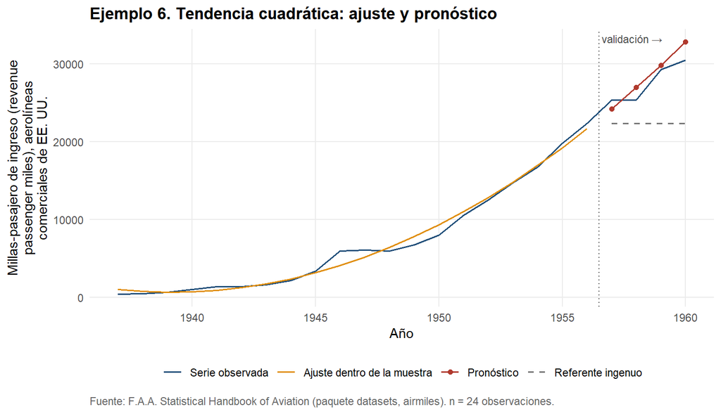

```r
.grafico_pronostico(d, fit$yhat, pron, ref, "Ejemplo 6. Tendencia cuadrática: ajuste y pronóstico")
```

## 8.8 Conclusión

La tendencia cuadrática fue la que mejor representó esta serie. El término cuadrático resultó significativo con error estándar robusto ($t =$ 10,81, valor p < 0,001) y en la validación el MASE fue 1,2055 frente a 4,4959 del ingenuo, mientras que el MSE se redujo en 92,67 %.

También superó a las alternativas lineal y exponencial (MASE 6,3852 y 19,8685). Sin embargo, las pruebas sobre los residuos muestran que todavía existe autocorrelación (Ljung–Box, valor p 0,001; Durbin–Watson 0,8489 frente a $d_L =$ 1,10), por lo que la parábola no logra explicar toda la dinámica de la serie. Además, solo hay 4 datos de validación, así que el resultado debe interpretarse con cierta precaución.

## 8.9 Recomendación

La tendencia cuadrática puede servir para pronósticos de corto plazo, aproximadamente de uno o dos años. En la validación los errores fueron relativamente pequeños en esos primeros horizontes (4,31 % y 6,42 % del valor observado).

El principal problema es que una parábola continúa creciendo cada vez más rápido. En el horizonte de 4 años el pronóstico fue 32859,43 frente a 30514,00 observado, un error de 7,69 %. Además, los primeros dos valores de validación fueron prácticamente iguales (25340,00 y 25343,00), mientras que el modelo seguía aumentando.

Por eso, no se recomienda extender este modelo demasiado lejos sin volver a estimarlo con nuevos datos.

# 9 Ejemplo 7. Tendencia exponencial sobre `JohnsonJohnson`

## 9.1 Descripción de la serie

```r
x <- JohnsonJohnson
d <- leer_serie(x,
                fuente = "Shumway RH, Stoffer DS (2000). Time Series Analysis and its Applications. Springer, Example 1.1 (paquete datasets, JohnsonJohnson)",
                unidad = "Ganancia trimestral por acción de Johnson & Johnson (dólares)")
s <- attr(d, "frecuencia")   # la serie es trimestral: el MASE y el ingenuo de referencia usan el período s
descripcion(x, "JohnsonJohnson", d)
```

| Campo | Valor |
| --- | --- |
| Nombre en R | JohnsonJohnson |
| Fuente (help) | Shumway RH, Stoffer DS (2000). Time Series Analysis and its Applications. Springer, Example 1.1 (paquete datasets, JohnsonJohnson) |
| Unidad | Ganancia trimestral por acción de Johnson & Johnson (dólares) |
| Frecuencia | 4 |
| Inicio (año, período) | 1960, 1 |
| Fin (año, período) | 1980, 4 |
| Rango de fechas | 1960-01-01 a 1980-10-01 |
| Observaciones | 84 |

La serie es trimestral, así que es **estacional** (período $s = 4$), y ese es el rasgo que este método no modela. Se elige de todos modos por su tendencia: la ganancia por acción crece a una tasa casi constante, que es el supuesto de la tendencia exponencial. Como la serie es estacional, el referente de comparación es el ingenuo estacional (el último ciclo repetido) y el MASE se escala con el ingenuo de período $s$. La sección de validación y la recomendación miden cuánto cuesta ignorar la estacionalidad.

## 9.2 Patrón de la serie

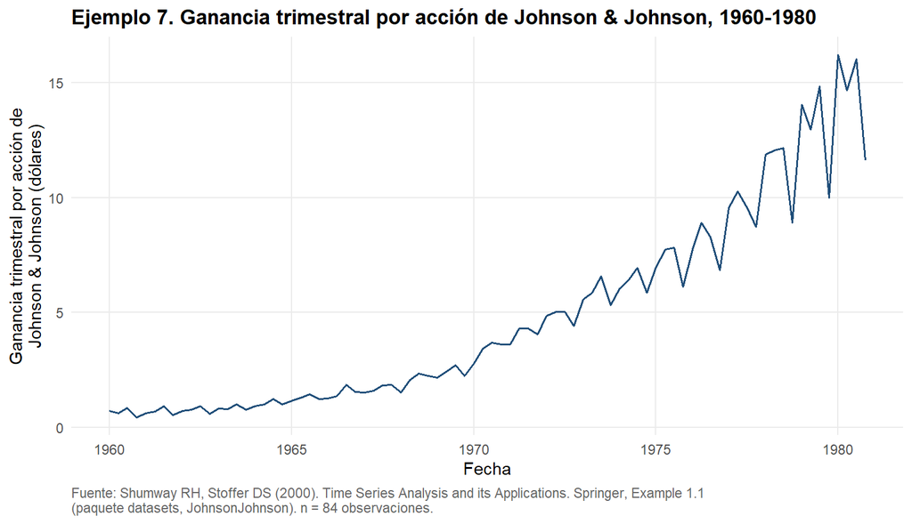

```r
graficar_serie(d, "Ejemplo 7. Ganancia trimestral por acción de Johnson & Johnson, 1960-1980")
```

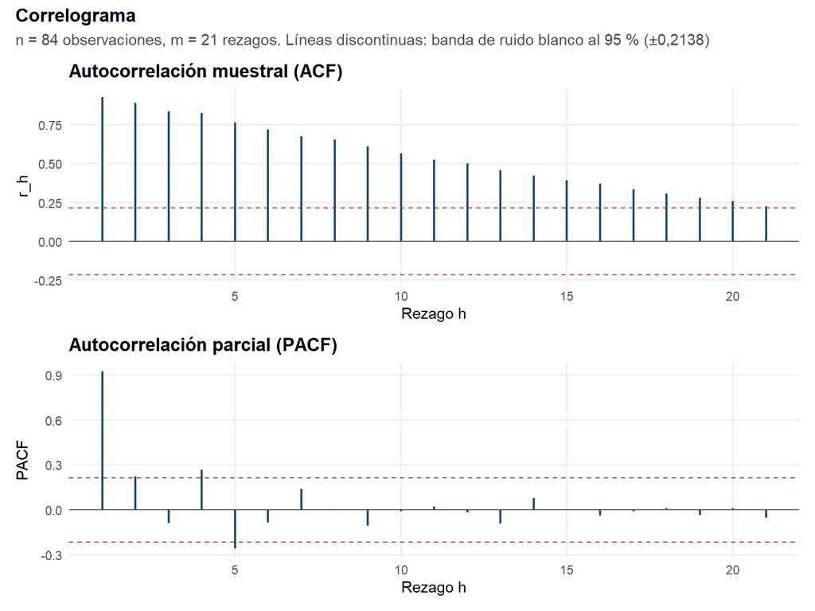

```r
cg <- correlograma(d)
cg$grafico
```

```r
n_total <- nrow(d)
r_1 <- .contraste_rh(cg$acf, n_total, 1)
pp(r_1, paste0("r_1 = ", n4(cg$acf[1]), ", casi 1, frente a una banda de ±", n4(cg$banda), ": cada trimestre repite casi entero al anterior, ",
               "como en una serie dominada por una tendencia creciente."))
```

**Contraste individual de la autocorrelación en el rezago h = 1** (n = 84)

1. **Hipótesis.** $H_0:\ \rho_{1} = 0$; $H_1:\ \rho_{1} \neq 0$.
2. **Estadístico y distribución bajo $H_0$.** $T^* = \dfrac{r_h}{\sqrt{1/n}} = \sqrt{n}\, r_h\ \overset{H_0}{\approx}\ N(0,1)$.
3. **Región de rechazo al 5 %.** $|T^*| > z_{0{,}975} = 1,9600$, es decir $|r_{1}| > 0,2138$.
4. **Valor observado.** estadístico observado = 8,4787; valor p < 0,001.
5. **Decisión.** Se rechaza $H_0$ (nivel de significancia del 5 %).
6. **Lectura.** r_1 = 0,9251, casi 1, frente a una banda de ±0,2138: cada trimestre repite casi entero al anterior, como en una serie dominada por una tendencia creciente.

```r
r_s <- .contraste_rh(cg$acf, n_total, s)
pp(r_s, paste0("En el rezago estacional h = ", s, " la autocorrelación vale ", n4(cg$acf[s]), ", significativa, pero no hay un pico sobre sus ",
               "vecinos (", n4(cg$acf[s - 1]), " en h = ", s - 1, " y ", n4(cg$acf[s + 1]), " en h = ", s + 1, "): la ACF de la serie original no deja ver la ",
               "estacionalidad porque la tendencia domina todos los rezagos. Se buscará en los errores, donde la tendencia ya no está."))
```

**Contraste individual de la autocorrelación en el rezago h = 4** (n = 84)

1. **Hipótesis.** $H_0:\ \rho_{4} = 0$; $H_1:\ \rho_{4} \neq 0$.
2. **Estadístico y distribución bajo $H_0$.** $T^* = \dfrac{r_h}{\sqrt{1/n}} = \sqrt{n}\, r_h\ \overset{H_0}{\approx}\ N(0,1)$.
3. **Región de rechazo al 5 %.** $|T^*| > z_{0{,}975} = 1,9600$, es decir $|r_{4}| > 0,2138$.
4. **Valor observado.** estadístico observado = 7,5528; valor p < 0,001.
5. **Decisión.** Se rechaza $H_0$ (nivel de significancia del 5 %).
6. **Lectura.** En el rezago estacional h = 4 la autocorrelación vale 0,8241, significativa, pero no hay un pico sobre sus vecinos (0,8328 en h = 3 y 0,7638 en h = 5): la ACF de la serie original no deja ver la estacionalidad porque la tendencia domina todos los rezagos. Se buscará en los errores, donde la tendencia ya no está.

```r
lb0 <- ljung_box(cg$acf, n_total, cg$m, 0)
pp(lb0, paste0("Q = ", n4(lb0$estadistico), " con ", lb0$gl, " grados de libertad y valor p ", pv(lb0$valor_p),
               ": los ", cg$m, " rezagos salen de la banda y la serie no es ruido blanco."))
```

**Prueba de Ljung–Box** (n = 84)

1. **Hipótesis.** $H_0:\ \rho_1 = \rho_2 = \cdots = \rho_m = 0$; $H_1:\ \exists\, h \le m$ con $\rho_h \neq 0$.
2. **Estadístico y distribución bajo $H_0$.** $Q_m = T(T+2)\sum_{h=1}^{m} \dfrac{r_h^2}{T-h}\ \overset{H_0}{\sim}\ \chi^2_{m-p}$; $m = 21$, $p = 0$, luego los grados de libertad son $m - p = 21$.
3. **Región de rechazo al 5 %.** $Q_m > \chi^2_{0{,}95;\,21} = 32,6706$.
4. **Valor observado.** estadístico observado = 685,3507; valor p < 0,001.
5. **Decisión.** Se rechaza $H_0$ (nivel de significancia del 5 %).
6. **Lectura.** Q = 685,3507 con 21 grados de libertad y valor p < 0,001: los 21 rezagos salen de la banda y la serie no es ruido blanco.

**Lectura del patrón.** La serie crece de forma acelerada: el promedio de la primera mitad es 1,38 y el de la segunda 8,22. La aceleración es la de un crecimiento porcentual estable, no la de una parábola: en logaritmos el crecimiento es casi una recta, con una pendiente que apenas cambia de una mitad a otra.

```r
z <- log(d$y); ti <- seq_len(n_total)
pend <- function(i) cov(ti[i], z[i]) / var(ti[i])   # pendiente de mínimos cuadrados de ln y sobre t
p_1 <- pend(1:42); p_2 <- pend(43:84)
```

La pendiente del logaritmo es 0,0396 en la primera mitad y 0,0343 en la segunda, es decir, una tasa de crecimiento de 4,04 % y 3,49 % por trimestre. Esa estabilidad de la tasa es el supuesto de la tendencia exponencial $Y_t = \beta_0 \beta_1^{\,t}$ (o $\ln Y_t = a + \theta t$). Contrasta con `airmiles` (ejemplo 6), donde la tasa cae a casi la mitad entre mitades.

## 9.3 Partición

```r
h <- min(12, floor(0.2 * n_total)); T_est <- n_total - h
est <- d[seq_len(T_est), ]; val <- d[T_est + seq_len(h), ]
```

Con $T = 84$ y $h = \min\{12, \lfloor 0{,}2 \cdot 84\rfloor\} = 12$ (tres años, que cubre 3 ciclos completos), el tramo de estimación va de 1960-01-01 a 1977-10-01 ($T_{est} = 72$) y el de validación de 1978-01-01 a 1980-10-01.

## 9.4 Ajuste y medidas

La tendencia exponencial no tiene constantes por elegir (los coeficientes salen de las ecuaciones normales sobre $\ln Y_t$), así que no se usa `optimizar()`. El pronóstico $e^{\hat a + \hat\theta t}$ estima la **mediana** condicional y no la media; más abajo se mide el efecto de la corrección de sesgo. Los `yhat` son valores ajustados de una regresión que usa todo el tramo de estimación.

```r
fit <- ajustar_tendencia(est$y, "exponencial")
p <- fit$parametros
pron <- fit$pronosticar(h)
ref <- rep(tail(est$y, s), length.out = h)        # ingenuo estacional: el último ciclo repetido
m_in <- .medir(est$y, fit$yhat, est$y, s)         # ajuste dentro del tramo de estimación
m_val <- .medir(val$y, pron, est$y, s)            # h pronósticos sobre el tramo de validación
m_ref <- .medir(val$y, ref, est$y, s)             # el ingenuo estacional, mismo tramo y mismo h
tab(.tabla_medidas(m_in, m_val, m_ref, "Ingenuo estacional"))
```

| caso | N | MSE | MAD | MAPE | MASE |
| --- | --- | --- | --- | --- | --- |
| Método, un paso (estimación) | 72 | 0,3222 | 0,3637 | 11,8986 | 0,6927 |
| Método, h pronósticos (validación) | 12 | 7,7384 | 1,8450 | 16,5379 | 3,5142 |
| Ingenuo estacional, h pronósticos (validación) | 12 | 15,5810 | 3,4275 | 24,6506 | 6,5286 |

```r
fit_c <- ajustar_tendencia(est$y, "exponencial", corregir_sesgo = TRUE)   # con la corrección de sesgo
m_c <- .medir(val$y, fit_c$pronosticar(h), est$y, s)
e_m <- val$y - pron; e_r <- val$y - ref           # errores de validación del método y del referente
```

En escala original el modelo es $\hat Y_t = 0,4982 \cdot 1,0437^{\,t}$: un nivel de 0,50 dólares en $t = 0$ y un crecimiento de 4,37 % por trimestre. El método supera al ingenuo estacional en validación: MASE 3,5142 contra 6,5286, MSE 7,74 contra 15,58 (50,33 % menos) y MAPE 16,54 % contra 24,65 %. El MASE es mayor que uno en las dos filas de validación porque se escala con el error del ingenuo estacional de un ciclo dentro de la muestra (0,5250), muy pequeño en una serie que crece despacio; lo que corresponde comparar es la última fila.

**Corrección de sesgo.** Multiplicar por $e^{\hat\sigma^2_{ln}/2} =$ 1,0115 no ayuda en validación: el MSE pasa de 7,74 a 8,33. El factor es pequeño (1,15 %) porque $\hat\sigma^2_{ln} =$ 0,0228 es pequeña, y en este tramo el pronóstico ya quedó por encima de lo observado, de modo que subirlo más solo empeora. Se mantiene el pronóstico sin corregir (la mediana).